# Análisis de Subtipos Moleculares en Cáncer de Tiroides

## 1. Planteamiento del Problema

### 1.1 Contexto clínico: el cáncer de tiroides

El cáncer de tiroides (thyroid carcinoma, THCA) es la neoplasia endocrina más frecuente a nivel mundial, con una incidencia que ha aumentado de manera sostenida durante las últimas décadas. En Estados Unidos, representa el 2.1% de todos los nuevos casos de cáncer diagnosticados anualmente, [con aproximadamente 45,240 nuevos casos estimados para 2026](https://www.cancer.org/cancer/types/thyroid-cancer/about/key-statistics.html), de los cuales 32,000 corresponden a mujeres y 13,240 a hombres. En España, [las estimaciones para 2024 apuntan a 6,345 nuevos diagnósticos](https://www.aecat.net/2024/02/07/segun-la-redecan-se-estiman-6-345-nuevos-casos-de-cancer-de-tiroides-en-2024/), donde aproximadamente tres cuartas partes de los pacientes serán mujeres (4,775 casos) frente a una cuarta parte de hombres (1,570 casos).

Esta marcada predominancia femenina es una característica global de la enfermedad: el cáncer de tiroides es casi tres veces más común en mujeres que en hombres, con una edad promedio de diagnóstico de 51 años. A pesar del aumento en la incidencia observado en décadas anteriores, atribuido en gran medida a un sobrediagnóstico derivado del uso más extendido de técnicas de imagen, las tasas de incidencia en EE.UU. han mostrado una tendencia a la baja desde 2014, disminuyendo aproximadamente un 2% por año. La mortalidad, por su parte, se mantiene relativamente baja: [la tasa de supervivencia relativa a 5 años es del 98.4%](https://www.nfcr.org/cancer-types/cancer-types-thyroid-cancer/), en parte porque la mayoría de los cánceres de tiroides responden bien al tratamiento.

Histológicamente, el cáncer de tiroides se clasifica en cuatro subtipos principales:

- **Carcinoma Papilar de Tiroides (PTC):** el más frecuente, representando entre el 79% y el 85% de los casos, con una tasa de supervivencia a 5 años del 97.7% y buen pronóstico general.
- **Carcinoma Folicular de Tiroides (FTC):** representa entre el 10% y el 15% de los casos, con mayor tendencia a metástasis hematógenas y mayor prevalencia en zonas con deficiencia de yodo.
- **Carcinoma Medular de Tiroides (MTC):** origina en las células parafoliculares C, representa ~4% de los cánceres de tiroides y tiene un componente hereditario significativo asociado a mutaciones en el gen *RET*.
- **Carcinoma Anaplásico de Tiroides (ATC):** representa apenas el 2% de las neoplasias tiroideas, pero es el subtipo más agresivo, con una tasa de supervivencia a 5 años del 4% en etapas avanzadas.

[figure not shown]

*Figura 1. Anatomía de la glándula tiroides y localización en el cuello. Fuente: National Cancer Institute (NCI), cancer.gov. Imagen de dominio público.*

A pesar de esta clasificación histológica establecida, estudios moleculares recientes han demostrado que dentro de cada subtipo existen subgrupos con perfiles de expresión génica distintos, respuestas diferenciales al tratamiento y pronósticos variables. Esta heterogeneidad molecular no siempre es capturada por la clasificación clínica tradicional, lo que motiva el uso de técnicas computacionales para explorar la estructura latente de los datos.

### 1.2 Relevancia del análisis molecular

El perfil de expresión génica ofrece una ventana sin precedentes hacia la biología del cáncer, capturando el estado funcional de la célula tumoral y reflejando las vías moleculares activas en el momento del muestreo. En el cáncer de tiroides, estudios genómicos han identificado alteraciones recurrentes en genes como *BRAF*, *RAS*, *RET*, *TERT* y *TP53*, cada uno asociado con subtipos moleculares y comportamientos clínicos específicos.

El [estudio seminal del TCGA sobre PTC](https://pmc.ncbi.nlm.nih.gov/articles/PMC6435845/) identificó dos subtipos moleculares principales basados en el perfil de expresión génica: el subtipo *BRAF V600E-like* (BVL) y el subtipo *RAS-like* (RL), representando una clasificación molecular que va más allá de la histopatología tradicional. El subtipo BVL se asocia con una activación robusta de la vía MAPK, menor diferenciación y reducida respuesta al yodo radiactivo, mientras que el subtipo RL presenta una activación dual de las vías MAPK y PI3K/AKT con mayor grado de diferenciación. Posteriormente se propuso un tercer subgrupo denominado *non-BRAF-non-RAS* (NBNR), asociado a un comportamiento más indolente.

Estas alteraciones moleculares se distribuyen de forma diferenciada entre subtipos: la mutación *BRAF V600E* se detecta en aproximadamente el 62% de los PTC, mientras que las mutaciones *RAS* aparecen en el 13% de los PTC, en el 40–50% de los FTC y en el 20–40% de los tumores pobremente diferenciados. Las mutaciones en el promotor de *TERT*, marcador de progresión tumoral, se detectan en el 10% de los PTC, el 17% de los FTC, y aumentan hasta el 73% en los ATC.

El aprendizaje no supervisado permite abordar este problema de forma integral, identificando grupos de pacientes con patrones de expresión global similares sin necesidad de imponer etiquetas previas. Esto es especialmente valioso en datos de alta dimensionalidad como los de RNAseq, donde cada muestra se caracteriza por la expresión de más de 60,000 genes.

### 1.3 Fuente de datos: TCGA-THCA vía UCSC Xena

Los datos utilizados en este proyecto provienen de **The Cancer Genome Atlas (TCGA)**, el programa de perfilado molecular más comprehensivo de cánceres humanos jamás realizado, financiado por el National Cancer Institute (NCI) de los Estados Unidos. TCGA ha caracterizado molecularmente más de 11,000 pacientes con 33 tipos distintos de cáncer.

Específicamente, se accedió al cohort **GDC TCGA Thyroid Cancer (THCA)** a través de la plataforma [**UCSC Xena**](https://xenabrowser.net/datapages/), que proporciona acceso estandarizado y armonizado a los datos procesados por el Genomic Data Commons (GDC) del NCI.

| Dataset | Nombre en Xena | Muestras | Descripción |
| --- | --- | --- | --- |
| Expresión génica | `TCGA-THCA.star_tpm.tsv` | 572 | STAR – TPM, log2(TPM+1) |
| Fenotipo clínico | `TCGA-THCA.clinical.tsv` | 580 | 83 variables clínicas |
| Datos de supervivencia | `TCGA-THCA.survival.tsv` | 579 | Estado vital y seguimiento |

Los valores de expresión génica están normalizados en unidades de **TPM (Transcripts Per Million)**, transformados como log2(TPM+1), lo cual estabiliza la varianza y prepara los datos para análisis estadísticos y de machine learning.

### 1.4 Objetivo general y preguntas de investigación

El objetivo general de este proyecto es aplicar técnicas de **aprendizaje no supervisado** para identificar subgrupos moleculares en el cáncer de tiroides a partir de datos de expresión génica, explorando si dichos subgrupos presentan características clínicas diferenciadas.

De manera específica, este análisis busca responder las siguientes preguntas:

1. ¿Es posible identificar subgrupos de pacientes con perfiles de expresión génica distintos dentro del cohort TCGA-THCA?
2. ¿Cuántos subgrupos moleculares emergen de manera natural en los datos, y qué tan robustos son?
3. ¿Qué genes contribuyen en mayor medida a diferenciar los subgrupos identificados?
4. ¿Los subgrupos moleculares se asocian con variables clínicas relevantes como estadio, género o edad?
5. ¿Los resultados son consistentes con los hallazgos reportados en la literatura científica?

### 1.5 Estructura del reporte

- **Sección 3:** Exploración y comprensión del conjunto de datos
- **Sección 4:** Preparación y tratamiento de los datos
- **Sección 5:** Reducción de dimensionalidad mediante PCA
- **Sección 6:** Construcción y comparación de modelos de clustering
- **Sección 7:** Interpretación de los clusters – análisis de genes
- **Sección 8:** Interpretación de los clusters – análisis clínico
- **Sección 9:** Discusión y comparación con literatura científica
- **Sección 10:** Conclusiones y reflexión final

## 2. Configuración del Entorno y Carga de Datos

Antes de iniciar el análisis, es necesario instalar y cargar todas las librerías requeridas. La librería principal para el acceso a los datos es `xenaPython`, que proporciona una interfaz programática con la plataforma UCSC Xena. Las demás librerías son estándar en el ecosistema de ciencia de datos en Python:

- **`xenaPython`**: acceso a datos del TCGA vía UCSC Xena
- **`pandas`**: manipulación y análisis de datos tabulares
- **`numpy`**: operaciones numéricas y matriciales
- **`matplotlib` / `seaborn`**: visualización estática de datos
- **`scikit-learn`**: algoritmos de machine learning (PCA, K-means, clustering jerárquico)
- **`scipy`**: pruebas estadísticas y construcción de dendrogramas

```python
!pip install xenaPython -q
print("✅ Instalación completada")
```

```
✅ Instalación completada
```

Con las librerías instaladas, se procede a importarlas y configurar los parámetros visuales globales que se utilizarán a lo largo de todo el reporte:

```python
import xenaPython as xena
import pandas as pd
import numpy as np
import matplotlib.pyplot as plt
import seaborn as sns
from scipy import stats
from scipy.cluster.hierarchy import dendrogram, linkage
from sklearn.preprocessing import StandardScaler
from sklearn.decomposition import PCA
from sklearn.cluster import KMeans, AgglomerativeClustering
from sklearn.metrics import silhouette_score, calinski_harabasz_score
import warnings
warnings.filterwarnings("ignore")

# Configuración visual global
sns.set_style("whitegrid")
plt.rcParams["figure.dpi"] = 120
plt.rcParams["font.size"]  = 11

print("✅ Librerías cargadas correctamente")
```

```
✅ Librerías cargadas correctamente
```

### 2.1 Conexión a UCSC Xena

UCSC Xena organiza los datos en *cohorts* (grupos de pacientes) y *datasets* (tipos de datos dentro de cada cohort). Para este proyecto se utilizará el cohort **GDC TCGA Thyroid Cancer (THCA)**, accediendo exclusivamente a los siguientes tres datasets:

| Dataset | Nombre en Xena | Descripción |
| --- | --- | --- |
| Expresión génica | `TCGA-THCA.star_tpm.tsv` | STAR–TPM, transformado como log2(TPM+1) |
| Fenotipo clínico | `TCGA-THCA.clinical.tsv` | 83 variables clínicas y demográficas |
| Supervivencia | `TCGA-THCA.survival.tsv` | Estado vital y tiempo de seguimiento |

A continuación se establece la conexión y se verifica que los datasets estén disponibles y correctamente cargados en el servidor:

```python
host   = "https://gdc.xenahubs.net"
cohort = "GDC TCGA Thyroid Cancer (THCA)"

dataset_expr  = "TCGA-THCA.star_tpm.tsv"
dataset_pheno = "TCGA-THCA.clinical.tsv"
dataset_surv  = "TCGA-THCA.survival.tsv"

# Verificar status dos datasets
datasets_info = xena.dataset_list(host, [cohort])
targets = [dataset_expr, dataset_pheno, dataset_surv]

print(f"=== Verificación de datasets – {cohort} ===\n")
for d in datasets_info:
    if d["name"] in targets:
        print(f"  ✅ {d['name']}")
        print(f"     Muestras : {d['count']}")
        print(f"     Tipo     : {d['type']}")
        print(f"     Status   : {d['status']}\n")
```

```
=== Verificación de datasets – GDC TCGA Thyroid Cancer (THCA) ===

  ✅ TCGA-THCA.clinical.tsv
     Muestras : 580
     Tipo     : clinicalMatrix
     Status   : loaded

  ✅ TCGA-THCA.star_tpm.tsv
     Muestras : 572
     Tipo     : genomicMatrix
     Status   : loaded

  ✅ TCGA-THCA.survival.tsv
     Muestras : 579
     Tipo     : clinicalMatrix
     Status   : loaded
```

### 2.2 Carga de muestras y genes

Con la conexión verificada, se procede a obtener la lista de muestras (pacientes) disponibles en el dataset de expresión génica, así como el número total de genes medidos. Estas dos dimensiones — **muestras y genes** — definen el tamaño del espacio de análisis:

```python
# Muestras disponibles en el dataset de expresión génica
samples = xena.dataset_samples(host, dataset_expr, None)
genes   = xena.dataset_field(host, dataset_expr)

print("=== Dataset de Expresión Génica ===")
print(f"  Muestras (pacientes) : {len(samples)}")
print(f"  Genes                : {len(genes):,}")
print(f"\n  Ejemplo de IDs de muestra : {samples[:3]}")
print(f"  Ejemplo de genes          : {genes[:3]}")
```

```
=== Dataset de Expresión Génica ===
  Muestras (pacientes) : 572
  Genes                : 60,661

  Ejemplo de IDs de muestra : ['TCGA-EM-A1CW-01A', 'TCGA-EL-A3ZN-01A', 'TCGA-DJ-A4UP-01A']
  Ejemplo de genes          : ['ENSG00000000003.15', 'ENSG00000000005.6', 'ENSG00000000419.13']
```

A continuación se cargan las variables clínicas y de supervivencia. En esta etapa se obtienen todos los campos disponibles sin ningún filtro, con el único propósito de conocer el contenido del dataset:

```python
# Cargar TODAS las variables clínicas disponibles
all_clinical_fields = xena.dataset_field(host, dataset_pheno)
all_clinical_data   = xena.dataset_fetch(host, dataset_pheno, samples, all_clinical_fields)
df_all_clinical     = pd.DataFrame(all_clinical_data,
                                   index=all_clinical_fields,
                                   columns=samples).T
df_all_clinical.index.name = "sample_id"

print("=== Dataset Clínico (fenotipo) ===")
print(f"  Muestras   : {df_all_clinical.shape[0]}")
print(f"  Variables  : {df_all_clinical.shape[1]}")
print(f"\n  Variables disponibles:")
for f in all_clinical_fields:
    print(f"    - {f}")
```

```
=== Dataset Clínico (fenotipo) ===
  Muestras   : 572
  Variables  : 83

  Variables disponibles:
    - age_at_diagnosis.diagnoses
    - age_at_earliest_diagnosis.diagnoses.xena_derived
    - age_at_earliest_diagnosis_in_years.diagnoses.xena_derived
    - age_at_index.demographic
    - ajcc_pathologic_m.diagnoses
    - ajcc_pathologic_n.diagnoses
    - ajcc_pathologic_stage.diagnoses
    - ajcc_pathologic_t.diagnoses
    - ajcc_staging_system_edition.diagnoses
    - alcohol_history.exposures
    - annotation_id.annotations
    - bcr_id.tissue_source_site
    - case_id
    - case_id.annotations
    - case_submitter_id.annotations
    - category.annotations
    - classification.annotations
    - classification_of_tumor.diagnoses
    - code.tissue_source_site
    - composition.samples
    - created_datetime.annotations
    - created_datetime.treatments.diagnoses
    - days_to_birth.demographic
    - days_to_collection.samples
    - days_to_death.demographic
    - days_to_diagnosis.diagnoses
    - days_to_last_follow_up.diagnoses
    - disease_type
    - disease_type.project
    - entity_id.annotations
    - entity_submitter_id.annotations
    - entity_type.annotations
    - ethnicity.demographic
    - gender.demographic
    - icd_10_code.diagnoses
```

[output cut: 33 more lines]

```
    - synchronous_malignancy.diagnoses
    - tissue_or_organ_of_origin.diagnoses
    - tissue_source_site_id.tissue_source_site
    - tissue_type.samples
    - treatment_id.treatments.diagnoses
    - treatment_or_therapy.treatments.diagnoses
    - treatment_type.treatments.diagnoses
    - tumor_descriptor.samples
    - tumor_grade.diagnoses
    - updated_datetime.annotations
    - updated_datetime.treatments.diagnoses
    - vital_status.demographic
    - year_of_birth.demographic
    - year_of_death.demographic
    - year_of_diagnosis.diagnoses
```

```python
# Cargar dataset de supervivencia
surv_fields = xena.dataset_field(host, dataset_surv)
surv_data   = xena.dataset_fetch(host, dataset_surv, samples, surv_fields)
df_surv     = pd.DataFrame(surv_data, index=surv_fields, columns=samples).T
df_surv.index.name = "sample_id"

print("=== Dataset de Supervivencia ===")
print(f"  Muestras  : {df_surv.shape[0]}")
print(f"  Variables : {df_surv.shape[1]}")
print(f"\n  Variables disponibles:")
for f in surv_fields:
    print(f"    - {f}")
print(f"\n  Primeras filas:")
df_surv.head()
```

```
=== Dataset de Supervivencia ===
  Muestras  : 572
  Variables : 4

  Variables disponibles:
    - OS
    - OS.time
    - _PATIENT
    - sampleID

  Primeras filas:
```

| sample_id | OS | OS.time | _PATIENT | sampleID |
| --- | --- | --- | --- | --- |
| TCGA-EM-A1CW-01A | 0 | 549 | 129 | 144 |
| TCGA-EL-A3ZN-01A | 0 | 1614 | 395 | 437 |
| TCGA-DJ-A4UP-01A | 0 | 916 | 235 | 264 |
| TCGA-EM-A3AO-01A | 0 | 1354 | 359 | 398 |
| TCGA-EL-A4KI-01A | 0 | 727 | 192 | 215 |

### 2.3 Resumen de los datos cargados

Los tres datasets han sido cargados exitosamente. A continuación se presenta un resumen de las dimensiones de cada uno:

| Dataset | Muestras | Variables | Notas |
| --- | --- | --- | --- |
| Expresión génica | 572 | 60,661 | log2(TPM+1) por gen |
| Fenotipo clínico | 572 | 83 | Variables clínicas y demográficas |
| Supervivencia | 572 | — | Estado vital y tiempo de seguimiento |

El análisis detallado del contenido, la selección de variables y la exploración de distribuciones se presenta en la siguiente sección.

## 3. Exploración y Comprensión del Conjunto de Datos

Esta sección tiene como objetivo comprender la estructura, el tamaño y el contenido de los datos antes de proceder al análisis. Se realizará una revisión sistemática que incluye la descripción de las dimensiones del dataset, un diccionario de variables, la selección justificada de variables clínicas, la identificación de valores faltantes, el análisis de distribuciones y la detección de posibles valores atípicos.

### 3.1 Estructura y tamaño del dataset

El dataset principal de este análisis es el de expresión génica, que constituye la base para la aplicación de las técnicas de aprendizaje no supervisado. A continuación se verifica su estructura y dimensiones:

```python
print("=" * 55)
print("  RESUMEN GENERAL DEL DATASET TCGA-THCA")
print("=" * 55)
print(f"\n  Dataset de expresión génica (STAR-TPM):")
print(f"    • Muestras (pacientes) : {len(samples):,}")
print(f"    • Genes                : {len(genes):,}")
print(f"\n  Dataset clínico (fenotipo):")
print(f"    • Muestras             : {df_all_clinical.shape[0]:,}")
print(f"    • Variables totales    : {df_all_clinical.shape[1]:,}")
print(f"\n  Dataset de supervivencia:")
print(f"    • Muestras             : {df_surv.shape[0]:,}")
print(f"    • Variables            : {df_surv.shape[1]:,}")
print("=" * 55)
```

```
=======================================================
  RESUMEN GENERAL DEL DATASET TCGA-THCA
=======================================================

  Dataset de expresión génica (STAR-TPM):
    • Muestras (pacientes) : 572
    • Genes                : 60,661

  Dataset clínico (fenotipo):
    • Muestras             : 572
    • Variables totales    : 83

  Dataset de supervivencia:
    • Muestras             : 572
    • Variables            : 4
=======================================================
```

El dataset de expresión génica comprende **572 pacientes** y **60,661 genes**, lo que representa un espacio de muy alta dimensionalidad. Esta característica es típica de los datos transcriptómicos y hace indispensable la aplicación de técnicas de reducción de dimensionalidad antes del clustering, como se describirá en la Sección 4.

El dataset clínico contiene **83 variables** en total, cuyo análisis y selección se detalla en las subsecciones siguientes.

### 3.2 Diccionario de variables clínicas

Dado que los nombres de las variables clínicas en el dataset de Xena no son autoexplicativos — utilizan una nomenclatura técnica basada en la estructura del GDC (Genomic Data Commons) del NCI — se presenta a continuación un diccionario con la descripción, tipo y valores posibles de las variables más relevantes, agrupadas por categoría temática:

```python
diccionario = {
    "DEMOGRÁFICAS": {
        "gender.demographic":
            ("Sexo biológico del paciente", "Categórica", "female / male"),
        "age_at_index.demographic":
            ("Edad en años al momento del diagnóstico", "Numérica", "15 – 89 años"),
        "race.demographic":
            ("Raza autodeclarada por el paciente", "Categórica",
             "white / black or african american / asian / american indian or alaska native"),
        "ethnicity.demographic":
            ("Origen étnico autodeclarado", "Categórica",
             "hispanic or latino / not hispanic or latino"),
        "vital_status.demographic":
            ("Estado vital al momento del último seguimiento", "Categórica", "Alive / Dead"),
        "days_to_death.demographic":
            ("Días desde el diagnóstico hasta el fallecimiento", "Numérica",
             "Solo disponible para pacientes fallecidos"),
    },
    "DIAGNÓSTICO Y ESTADIFICACIÓN": {
        "primary_diagnosis.diagnoses":
            ("Subtipo histológico del tumor según clasificación ICD-O", "Categórica",
             "Papillary adenocarcinoma NOS / Papillary carcinoma follicular variant / etc."),
        "ajcc_pathologic_stage.diagnoses":
            ("Estadio tumoral global según clasificación AJCC", "Categórica ordinal",
             "Stage I / Stage II / Stage III / Stage IVA / Stage IVC"),
        "ajcc_pathologic_t.diagnoses":
            ("Extensión del tumor primario según TNM (T)", "Categórica ordinal",
             "T1a / T1b / T2 / T3 / T4a / TX"),
        "ajcc_pathologic_n.diagnoses":
            ("Afectación de ganglios linfáticos regionales según TNM (N)", "Categórica ordinal",
             "N0 / N1 / N1a / N1b / NX"),
        "ajcc_pathologic_m.diagnoses":
            ("Presencia de metástasis a distancia según TNM (M)", "Categórica ordinal",
             "M0 / M1 / MX"),
        "tumor_grade.diagnoses":
            ("Grado histológico del tumor (agresividad celular)", "Categórica ordinal",
             "G1 / G2 / G3 / G4 / GX"),
        "progression_or_recurrence.diagnoses":
            ("Indica si hubo progresión o recurrencia documentada", "Categórica", "yes / no"),
    },
    "SUPERVIVENCIA Y SEGUIMIENTO": {
        "days_to_last_follow_up.diagnoses":
            ("Días desde el diagnóstico hasta el último seguimiento clínico",
             "Numérica", "—"),
    }
}

for categoria, variables in diccionario.items():
    print(f"\n{'='*70}")
    print(f"  {categoria}")
    print(f"{'='*70}")
    for var, (desc, tipo, valores) in variables.items():
        print(f"\n  📌 {var}")
        print(f"     Descripción : {desc}")
        print(f"     Tipo        : {tipo}")
        print(f"     Valores     : {valores}")
```

```
======================================================================
  DEMOGRÁFICAS
======================================================================

  📌 gender.demographic
     Descripción : Sexo biológico del paciente
     Tipo        : Categórica
     Valores     : female / male

  📌 age_at_index.demographic
     Descripción : Edad en años al momento del diagnóstico
     Tipo        : Numérica
     Valores     : 15 – 89 años

  📌 race.demographic
     Descripción : Raza autodeclarada por el paciente
     Tipo        : Categórica
     Valores     : white / black or african american / asian / american indian or alaska native

  📌 ethnicity.demographic
     Descripción : Origen étnico autodeclarado
     Tipo        : Categórica
     Valores     : hispanic or latino / not hispanic or latino

  📌 vital_status.demographic
     Descripción : Estado vital al momento del último seguimiento
     Tipo        : Categórica
     Valores     : Alive / Dead

  📌 days_to_death.demographic
     Descripción : Días desde el diagnóstico hasta el fallecimiento
     Tipo        : Numérica
     Valores     : Solo disponible para pacientes fallecidos

======================================================================
  DIAGNÓSTICO Y ESTADIFICACIÓN
======================================================================

  📌 primary_diagnosis.diagnoses
     Descripción : Subtipo histológico del tumor según clasificación ICD-O
```

[output cut: 26 more lines]

```
     Valores     : G1 / G2 / G3 / G4 / GX

  📌 progression_or_recurrence.diagnoses
     Descripción : Indica si hubo progresión o recurrencia documentada
     Tipo        : Categórica
     Valores     : yes / no

======================================================================
  SUPERVIVENCIA Y SEGUIMIENTO
======================================================================

  📌 days_to_last_follow_up.diagnoses
     Descripción : Días desde el diagnóstico hasta el último seguimiento clínico
     Tipo        : Numérica
     Valores     : —
```

### 3.3 Selección de variables clínicas

El dataset de fenotipo contiene **83 variables clínicas** en total. Sin embargo, no todas son igualmente útiles para el objetivo de este análisis. Una revisión preliminar del diccionario de variables revela que el dataset incluye metadatos administrativos, variables redundantes, variables técnicas de muestra y variables sin datos suficientes.

Para realizar una selección **objetiva, reproducible y justificada**, se aplican tres criterios de forma secuencial:

#### Criterio 1 — Completitud (umbral: ≤ 50% de valores faltantes)

Una variable con más del 50% de valores faltantes no contiene información suficiente para sustentar comparaciones confiables entre grupos de pacientes. El umbral del 50% es un estándar ampliamente utilizado en análisis de datos clínicos y garantiza que al menos la mitad de los pacientes tengan información disponible para cada variable retenida.

> **Acción:** se eliminan todas las variables que superen este umbral.

#### Criterio 2 — Varianza (umbral: más de 1 valor único)

Una variable con un único valor en toda la muestra tiene varianza cero: no diferencia a ningún paciente de otro y por tanto no puede contribuir a la interpretación de los clusters. Este caso es frecuente en cohorts específicos como THCA, donde variables como `disease_type` o `primary_site` tienen el mismo valor para todos los pacientes por definición.

> **Acción:** se eliminan todas las variables con un único valor observado.

#### Criterio 3 — Relevancia clínica (evaluación manual justificada)

Los dos criterios anteriores son cuantitativos y automáticos, pero no son suficientes por sí solos. En esta etapa se examina cada variable candidata restante y se toma una decisión explícita de inclusión o exclusión, documentando la razón en cada caso.

Los motivos de exclusión incluyen: redundancia de información, constancia implícita en el cohort, metadatos sin valor interpretativo y baja utilidad para el análisis de clustering transcriptómico.

> **Acción:** se seleccionan manualmente las variables con relevancia clínica documentada, descartando el resto con justificación explícita.

A continuación se ejecutan los tres criterios de forma secuencial:

```
Variables eliminadas por >50% missings : 16
Variables que pasan criterio 1         : 67
```

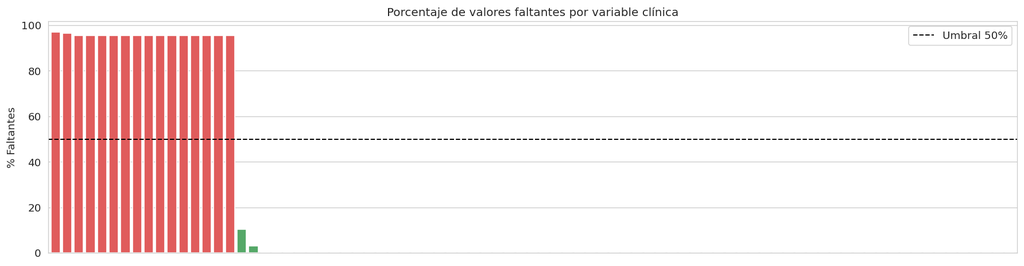

```
Variables eliminadas en criterio 1:
  ✗ annotation_id.annotations (95.5%)
  ✗ case_id.annotations (95.5%)
  ✗ case_submitter_id.annotations (95.5%)
  ✗ category.annotations (95.5%)
  ✗ classification.annotations (95.5%)
  ✗ created_datetime.annotations (95.5%)
  ✗ days_to_death.demographic (96.5%)
  ✗ entity_id.annotations (95.5%)
  ✗ entity_submitter_id.annotations (95.5%)
  ✗ entity_type.annotations (95.5%)
  ✗ notes.annotations (95.5%)
  ✗ state.annotations (95.5%)
  ✗ status.annotations (95.5%)
  ✗ submitter_id.annotations (95.5%)
  ✗ updated_datetime.annotations (95.5%)
  ✗ year_of_death.demographic (96.9%)
```

```python
# PASO 0: corregir missings enmascarados ANTES de aplicar cualquier criterio
df_all_clean = df_all_clinical.copy()
df_all_clean.replace(["NaN", "nan", "--", "N/A", "None", ""], np.nan, inplace=True)

# CRITERIO 1: completitud
missing_pct = (df_all_clean.isnull().sum() / len(df_all_clean) * 100).round(1)
vars_pass_completitud = missing_pct[missing_pct <= 50].index.tolist()
vars_fail_completitud = missing_pct[missing_pct  > 50].index.tolist()

print(f"Variables eliminadas por >50% missings : {len(vars_fail_completitud)}")
print(f"Variables que pasan criterio 1         : {len(vars_pass_completitud)}")

# Visualización
fig, ax = plt.subplots(figsize=(15, 4))
colors = ["#E05C5C" if v > 50 else "#55A868"
          for v in missing_pct.sort_values(ascending=False).values]
missing_pct.sort_values(ascending=False).plot(
    kind="bar", ax=ax, color=colors, edgecolor="white", width=0.8)
ax.axhline(50, color="black", linestyle="--", linewidth=1.2, label="Umbral 50%")
ax.set_title("Porcentaje de valores faltantes por variable clínica", fontsize=12)
ax.set_ylabel("% Faltantes")
ax.set_xticks([])
ax.legend()
plt.tight_layout()
plt.savefig("missings_criterio1.png", dpi=150, bbox_inches="tight")
plt.show()

print(f"\nVariables eliminadas en criterio 1:")
for v in sorted(vars_fail_completitud):
    print(f"  ✗ {v} ({missing_pct[v]}%)")
```

```python
# CRITERIO 2: varianza
df_filtered = df_all_clean[vars_pass_completitud].copy()
n_unique = df_filtered.nunique(dropna=True)

vars_zero_variance = n_unique[n_unique <= 1].index.tolist()
vars_pass_variance = n_unique[n_unique  > 1].index.tolist()

print(f"Variables eliminadas por varianza cero : {len(vars_zero_variance)}")
print(f"Variables que pasan criterio 2         : {len(vars_pass_variance)}")

print(f"\nVariables eliminadas en criterio 2:")
for v in sorted(vars_zero_variance):
    print(f"  ✗ {v}")

print(f"\nVariables candidatas restantes ({len(vars_pass_variance)}):")
for v in sorted(vars_pass_variance):
    print(f"  • {v}")
```

```
Variables eliminadas por varianza cero : 19
Variables que pasan criterio 2         : 48

Variables eliminadas en criterio 2:
  ✗ alcohol_history.exposures
  ✗ classification_of_tumor.diagnoses
  ✗ composition.samples
  ✗ days_to_diagnosis.diagnoses
  ✗ disease_type.project
  ✗ icd_10_code.diagnoses
  ✗ is_ffpe.samples
  ✗ last_known_disease_status.diagnoses
  ✗ name.program.project
  ✗ name.project
  ✗ primary_site
  ✗ primary_site.project
  ✗ progression_or_recurrence.diagnoses
  ✗ project.tissue_source_site
  ✗ project_id.project
  ✗ site_of_resection_or_biopsy.diagnoses
  ✗ state.treatments.diagnoses
  ✗ tissue_or_organ_of_origin.diagnoses
  ✗ tumor_grade.diagnoses

Variables candidatas restantes (48):
  • age_at_diagnosis.diagnoses
  • age_at_earliest_diagnosis.diagnoses.xena_derived
  • age_at_earliest_diagnosis_in_years.diagnoses.xena_derived
  • age_at_index.demographic
  • ajcc_pathologic_m.diagnoses
  • ajcc_pathologic_n.diagnoses
  • ajcc_pathologic_stage.diagnoses
  • ajcc_pathologic_t.diagnoses
  • ajcc_staging_system_edition.diagnoses
  • bcr_id.tissue_source_site
  • case_id
  • code.tissue_source_site
  • created_datetime.treatments.diagnoses
  • days_to_birth.demographic
  • days_to_collection.samples
```

[output cut: 18 more lines]

```
  • sample_type_id.samples
  • specimen_type.samples
  • submitter_id
  • submitter_id.treatments.diagnoses
  • synchronous_malignancy.diagnoses
  • tissue_source_site_id.tissue_source_site
  • tissue_type.samples
  • treatment_id.treatments.diagnoses
  • treatment_or_therapy.treatments.diagnoses
  • treatment_type.treatments.diagnoses
  • tumor_descriptor.samples
  • updated_datetime.treatments.diagnoses
  • vital_status.demographic
  • year_of_birth.demographic
  • year_of_diagnosis.diagnoses
```

```python
# CRITERIO 3: relevancia clínica
# Variables a descartar con justificación explícita
exclusion_reasons = {
    "created_datetime.treatments.diagnoses":
        "Metadato administrativo — fecha de creación del registro de tratamiento",
    "updated_datetime.treatments.diagnoses":
        "Metadato administrativo — fecha de actualización del registro",
    "submitter_id.treatments.diagnoses":
        "Identificador administrativo del tratamiento, sin valor clínico",
    "treatment_id.treatments.diagnoses":
        "Identificador administrativo del tratamiento, sin valor clínico",
    "tumor_descriptor.samples":
        "Valor casi constante (Primary en >95% de casos), sin capacidad discriminatoria",
    "case_id":
        "Identificador interno administrativo",
    "id":
        "Identificador interno administrativo",
    "submitter_id":
        "Identificador interno administrativo",
    "sampleID":
        "Identificador interno de muestra",
    "sample_id.samples":
        "Identificador interno de muestra, redundante",
    "disease_type":
        "Valor constante para todo el cohort (Thyroid Carcinoma)",
    "disease_type.project":
        "Valor constante para todo el cohort",
    "primary_site":
        "Valor constante para todo el cohort (Thyroid Gland)",
    "primary_site.project":
        "Valor constante para todo el cohort",
    "project_id.project":
        "Valor constante para todo el cohort (TCGA-THCA)",
    "name.program.project":
        "Valor constante para todo el cohort (TCGA)",
    "name.project":
        "Valor constante para todo el cohort",
    "name.tissue_source_site":
        "Metadato administrativo del sitio de origen",
    "code.tissue_source_site":
        "Metadato administrativo del sitio de origen",
    "bcr_id.tissue_source_site":
        "Identificador administrativo BCR",
    "project.tissue_source_site":
        "Metadato administrativo redundante",
    "tissue_source_site_id.tissue_source_site":
        "Metadato administrativo redundante",
    "sample_type.samples":
        "Valor casi constante (Primary Tumor en >99% de casos)",
    "sample_type_id.samples":
        "Duplicado numérico de sample_type.samples",
    "composition.samples":
        "Valor constante (Solid Tissue) para todo el cohort",
    "tissue_type.samples":
        "Valor casi constante (Tumor en >99% de casos)",
    "is_ffpe.samples":
        "Metadato técnico de preservación de muestra, sin relevancia clínica",
    "oct_embedded.samples":
        "Metadato técnico de preservación de muestra",
    "preservation_method.samples":
        "Metadato técnico de preservación de muestra",
    "specimen_type.samples":
        "Metadato técnico redundante con sample_type",
    "pathology_report_uuid.samples":
        "Identificador administrativo UUID",
    "days_to_collection.samples":
        "Metadato logístico sin relevancia clínica directa",
    "initial_weight.samples":
        "Metadato técnico del peso de la muestra",
    "days_to_birth.demographic":
        "Redundante con age_at_index (misma información en días)",
    "age_at_diagnosis.diagnoses":
        "Redundante con age_at_index (misma información en días)",
    "age_at_earliest_diagnosis.diagnoses.xena_derived":
        "Variable derivada por Xena, redundante con age_at_index",
    "age_at_earliest_diagnosis_in_years.diagnoses.xena_derived":
        "Variable derivada por Xena, redundante con age_at_index",
    "year_of_birth.demographic":
        "Redundante con age_at_index",
    "year_of_diagnosis.diagnoses":
        "Redundante con age_at_index",
    "days_to_diagnosis.diagnoses":
        "Redundante con age_at_index",
    "icd_10_code.diagnoses":
        "Código administrativo (C73 constante para todo el cohort THCA)",
    "morphology.diagnoses":
        "Código ICD-O morfológico, información ya capturada por primary_diagnosis",
    "tissue_or_organ_of_origin.diagnoses":
        "Valor constante (Thyroid gland) para todo el cohort",
    "site_of_resection_or_biopsy.diagnoses":
        "Valor constante (Thyroid gland) para todo el cohort",
    "classification_of_tumor.diagnoses":
        "Alta proporción de valores no informativos",
    "last_known_disease_status.diagnoses":
        "Alta proporción de valores 'unknown', baja utilidad interpretativa",
    "prior_malignancy.diagnoses":
        "Baja variabilidad, poco relevante para clustering transcriptómico",
    "prior_treatment.diagnoses":
        "Baja variabilidad, poco relevante para clustering transcriptómico",
    "synchronous_malignancy.diagnoses":
        "Baja variabilidad, poco relevante para clustering transcriptómico",
    "ajcc_staging_system_edition.diagnoses":
        "Metadato de la edición del sistema de estadificación, sin valor clínico",
    "treatment_type.treatments.diagnoses":
        "Alta variabilidad no estructurada, difícil de interpretar en clustering",
    "treatment_or_therapy.treatments.diagnoses":
        "Alta proporción de valores no informativos",
    "state.treatments.diagnoses":
        "Metadato administrativo del estado del registro",
    "state.annotations":
        "Metadato administrativo del estado del registro",
}

# Variables que deben incluirse aunque no pasaron criterios 1 o 2
# (eliminadas porque sus NaN estaban enmascarados como strings)
forced_include = {
    "days_to_death.demographic":
        "Variable de supervivencia fundamental — missings esperados (pacientes vivos)",
    "progression_or_recurrence.diagnoses":
        "Indicador de comportamiento clínico post-tratamiento",
    "tumor_grade.diagnoses":
        "Grado histológico relacionado con agresividad tumoral",
}

# Aplicar criterio 3
vars_selected  = []
vars_excluded  = []

for var in vars_pass_variance:
    if var in exclusion_reasons:
        vars_excluded.append((var, exclusion_reasons[var]))
    else:
        vars_selected.append(var)

# Agregar forzadas
for var, justif in forced_include.items():
    if var not in vars_selected:
        vars_selected.append(var)

# Resumen
print(f"{'='*70}")
print(f"  VARIABLES SELECCIONADAS ({len(vars_selected)})")
print(f"{'='*70}")
for v in sorted(vars_selected):
    origin = " ⟵ incluida por relevancia clínica" if v in forced_include else ""
    print(f"  ✅ {v}{origin}")

print(f"\n{'='*70}")
print(f"  VARIABLES DESCARTADAS EN CRITERIO 3 ({len(vars_excluded)})")
print(f"{'='*70}")
for v, reason in vars_excluded:
    print(f"  ✗ {v}")
    print(f"    → {reason}\n")

clinical_vars = sorted(vars_selected)
print(f"\n✅ Total de variables clínicas seleccionadas: {len(clinical_vars)}")
```

```
======================================================================
  VARIABLES SELECCIONADAS (14)
======================================================================
  ✅ age_at_index.demographic
  ✅ ajcc_pathologic_m.diagnoses
  ✅ ajcc_pathologic_n.diagnoses
  ✅ ajcc_pathologic_stage.diagnoses
  ✅ ajcc_pathologic_t.diagnoses
  ✅ days_to_death.demographic ⟵ incluida por relevancia clínica
  ✅ days_to_last_follow_up.diagnoses
  ✅ ethnicity.demographic
  ✅ gender.demographic
  ✅ primary_diagnosis.diagnoses
  ✅ progression_or_recurrence.diagnoses ⟵ incluida por relevancia clínica
  ✅ race.demographic
  ✅ tumor_grade.diagnoses ⟵ incluida por relevancia clínica
  ✅ vital_status.demographic

======================================================================
  VARIABLES DESCARTADAS EN CRITERIO 3 (37)
======================================================================
  ✗ age_at_diagnosis.diagnoses
    → Redundante con age_at_index (misma información en días)

  ✗ age_at_earliest_diagnosis.diagnoses.xena_derived
    → Variable derivada por Xena, redundante con age_at_index

  ✗ age_at_earliest_diagnosis_in_years.diagnoses.xena_derived
    → Variable derivada por Xena, redundante con age_at_index

  ✗ ajcc_staging_system_edition.diagnoses
    → Metadato de la edición del sistema de estadificación, sin valor clínico

  ✗ bcr_id.tissue_source_site
    → Identificador administrativo BCR

  ✗ case_id
    → Identificador interno administrativo

  ✗ code.tissue_source_site
```

[output cut: 79 more lines]

```

  ✗ tumor_descriptor.samples
    → Valor casi constante (Primary en >95% de casos), sin capacidad discriminatoria

  ✗ updated_datetime.treatments.diagnoses
    → Metadato administrativo — fecha de actualización del registro

  ✗ year_of_birth.demographic
    → Redundante con age_at_index

  ✗ year_of_diagnosis.diagnoses
    → Redundante con age_at_index


✅ Total de variables clínicas seleccionadas: 14
```

El proceso de descarte en el Criterio 3 se puede resumir en cinco categorías:

1. **Metadatos administrativos:** identificadores internos, fechas de registro y códigos de sitio — no tienen valor clínico ni analítico.
2. **Variables constantes en el cohort:** campos como `disease_type` o `primary_site` tienen el mismo valor para todos los pacientes del cohort THCA.
3. **Variables redundantes:** campos que duplican información ya capturada por otra variable seleccionada (edad en días vs. años, códigos morfológicos vs. diagnóstico).
4. **Metadatos técnicos de muestra:** información sobre preservación y logística de las muestras, relevante para control de calidad pero no para análisis clínico.
5. **Variables de baja utilidad clínica:** campos con alta proporción de valores desconocidos o sin correlato interpretable con los patrones de expresión génica.

Las **14 variables finalmente seleccionadas** cubren las dimensiones clínicas más relevantes para la interpretación de clusters transcriptómicos: perfil demográfico (género, edad, raza, etnicidad), estadificación tumoral completa (TNM + estadio AJCC), subtipo histológico, outcome clínico (supervivencia) y comportamiento post-tratamiento.

### 3.4 Decodificación de variables categóricas

Los datos originales de Xena codifican las variables categóricas como enteros. Para interpretar correctamente los resultados, se aplica el mapeo de cada código numérico a su categoría real, obtenido mediante la función `field_codes` de la API de Xena. Adicionalmente, se corrigen los valores faltantes enmascarados y se convierten las variables numéricas a su tipo correcto:

```python
# Cargar las variables seleccionadas
clinical_data = xena.dataset_fetch(host, dataset_pheno, samples, clinical_vars)
df_clinical   = pd.DataFrame(clinical_data, index=clinical_vars, columns=samples).T
df_clinical.index.name = "sample_id"

# Diccionario de decodificación
code_maps = {
    "gender.demographic": {
        0: "female", 1: "male"},
    "ajcc_pathologic_stage.diagnoses": {
        0: "Stage I",  1: "Stage III", 2: "Stage IVA",
        3: "Stage II", 4: np.nan,      5: "Stage IVC", 6: "Stage IV"},
    "ajcc_pathologic_t.diagnoses": {
        0: "T1a", 1: "T2",  2: "T3", 3: "T1",
        4: "T1b", 5: "T4a", 6: "TX", 7: "T4"},
    "ajcc_pathologic_n.diagnoses": {
        0: "N0", 1: "NX", 2: "N1a", 3: "N1b", 4: "N1"},
    "ajcc_pathologic_m.diagnoses": {
        0: "M0", 1: "MX", 2: np.nan, 3: "M1"},
    "vital_status.demographic": {
        0: "Alive", 1: "Dead"},
    "primary_diagnosis.diagnoses": {
        0: "Papillary carcinoma, follicular variant",
        1: "Papillary adenocarcinoma, NOS",
        2: "Papillary carcinoma, columnar cell",
        3: "Oxyphilic adenocarcinoma",
        4: "Carcinoma, NOS",
        5: "Nonencapsulated sclerosing carcinoma",
        6: "Follicular carcinoma, minimally invasive",
        7: "Follicular adenocarcinoma, NOS"},
    "race.demographic": {
        0: "white", 1: "black or african american",
        2: "asian",  3: np.nan,
        4: "american indian or alaska native"},
    "ethnicity.demographic": {
        0: "hispanic or latino", 1: "not hispanic or latino", 2: np.nan}
}

# Aplicar decodificación
df_decoded = df_clinical.copy()
for col, mapping in code_maps.items():
    if col in df_decoded.columns:
        df_decoded[col] = df_clinical[col].apply(
            lambda x: mapping.get(x, x) if x not in ["NaN","nan","--"] else np.nan)

# Corregir missings enmascarados
df_decoded.replace(["NaN","nan","--","N/A","None",""], np.nan, inplace=True)

# Convertir variables numéricas
for col in ["age_at_index.demographic",
            "days_to_last_follow_up.diagnoses",
            "days_to_death.demographic"]:
    if col in df_decoded.columns:
        df_decoded[col] = pd.to_numeric(df_decoded[col], errors="coerce")

print("✅ Decodificación completada")
print(f"   Shape final: {df_decoded.shape[0]} muestras × {df_decoded.shape[1]} variables\n")
df_decoded.head()
```

```
✅ Decodificación completada
   Shape final: 572 muestras × 14 variables
```

| sample_id | age_at_index.demographic | ajcc_pathologic_m.diagnoses | ajcc_pathologic_n.diagnoses | ajcc_pathologic_stage.diagnoses | ajcc_pathologic_t.diagnoses | days_to_death.demographic | days_to_last_follow_up.diagnoses | ethnicity.demographic | gender.demographic | primary_diagnosis.diagnoses | progression_or_recurrence.diagnoses | race.demographic | tumor_grade.diagnoses | vital_status.demographic |
| --- | --- | --- | --- | --- | --- | --- | --- | --- | --- | --- | --- | --- | --- | --- |
| TCGA-EM-A1CW-01A | 39 | MX | N0 | Stage I | T3 | NaN | 549.0 | NaN | female | Papillary carcinoma, follicular variant | 0 | NaN | 0 | Alive |
| TCGA-EL-A3ZN-01A | 28 | M0 | N1 | Stage I | T3 | NaN | 1614.0 | not hispanic or latino | female | Papillary adenocarcinoma, NOS | 0 | white | 0 | Alive |
| TCGA-DJ-A4UP-01A | 15 | M0 | N1b | Stage I | T1b | NaN | 916.0 | not hispanic or latino | female | Papillary adenocarcinoma, NOS | 0 | white | 0 | Alive |
| TCGA-EM-A3AO-01A | 61 | MX | N1b | Stage IVA | T2 | NaN | 1354.0 | NaN | male | Papillary adenocarcinoma, NOS | 0 | NaN | 0 | Alive |
| TCGA-EL-A4KI-01A | 63 | MX | N0 | Stage III | T3 | NaN | 727.0 | not hispanic or latino | male | Papillary adenocarcinoma, NOS | 0 | white | 0 | Alive |

### 3.5 Identificación de valores faltantes

Con los datos correctamente decodificados, se realiza una revisión sistemática de los valores faltantes reales en cada variable seleccionada:

```
=== Valores faltantes – variables seleccionadas ===

                                     Valores faltantes  Porcentaje (%)
days_to_death.demographic                          552            96.5
ethnicity.demographic                              121            21.2
race.demographic                                   104            18.2
days_to_last_follow_up.diagnoses                    18             3.1
ajcc_pathologic_stage.diagnoses                      2             0.3
ajcc_pathologic_m.diagnoses                          1             0.2
ajcc_pathologic_t.diagnoses                          0             0.0
ajcc_pathologic_n.diagnoses                          0             0.0
age_at_index.demographic                             0             0.0
gender.demographic                                   0             0.0
primary_diagnosis.diagnoses                          0             0.0
progression_or_recurrence.diagnoses                  0             0.0
tumor_grade.diagnoses                                0             0.0
vital_status.demographic                             0             0.0
```

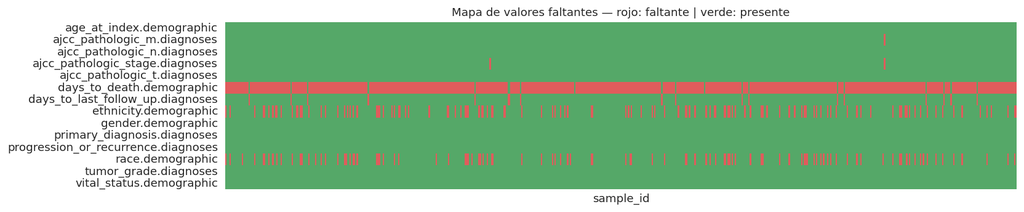

```python
missing_real = df_decoded.isnull().sum()
missing_pct2 = (missing_real / len(df_decoded) * 100).round(1)

df_missing = pd.DataFrame({
    "Valores faltantes": missing_real,
    "Porcentaje (%)": missing_pct2
}).sort_values("Porcentaje (%)", ascending=False)

print("=== Valores faltantes – variables seleccionadas ===\n")
print(df_missing.to_string())

# Heatmap de missings
fig, ax = plt.subplots(figsize=(14, 3))
sns.heatmap(df_decoded.isnull().astype(int).T,
            cmap=["#55A868","#E05C5C"],
            cbar=False, ax=ax, xticklabels=False)
ax.set_title("Mapa de valores faltantes — rojo: faltante | verde: presente",
             fontsize=11)
plt.tight_layout()
plt.savefig("heatmap_missings.png", dpi=150, bbox_inches="tight")
plt.show()
```

Los valores faltantes se concentran en tres variables:

- **`days_to_death` (96.5%):** clínicamente esperado — refleja que la gran mayoría de los pacientes estaban vivos al último seguimiento, como confirma `vital_status`.
- **`ethnicity` (21.2%) y `race` (18.2%):** pacientes que optaron por no reportar estas variables, frecuente en estudios multicéntricos de EE.UU.
- El resto de las variables presentan **completitud total o casi total**, lo que garantiza la solidez del análisis clínico posterior.

### 3.6 Análisis básico de distribuciones

Se visualiza la distribución de las principales variables clínicas para caracterizar la población del cohort TCGA-THCA:

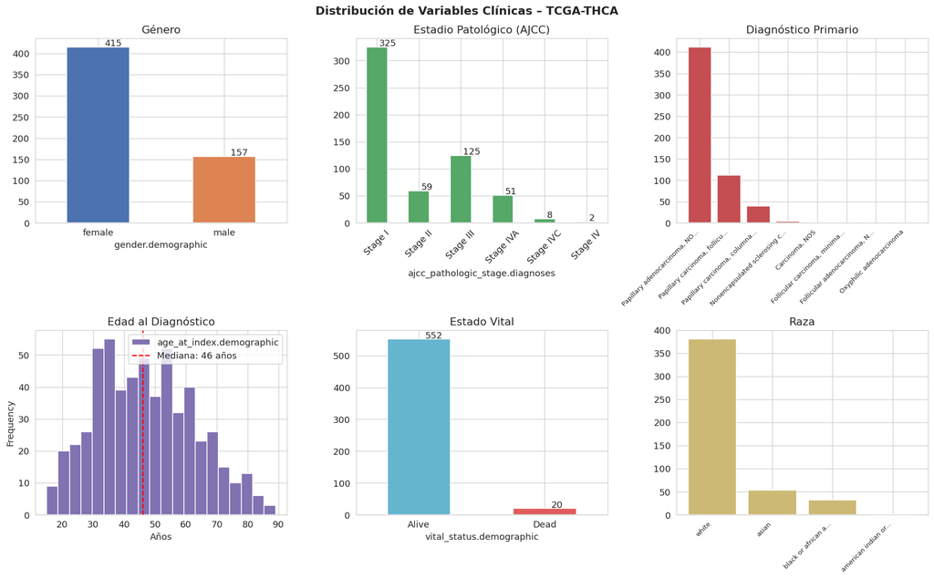

```python
fig, axes = plt.subplots(2, 3, figsize=(16, 10))
fig.suptitle("Distribución de Variables Clínicas – TCGA-THCA",
             fontsize=14, fontweight="bold")

# Género
df_decoded["gender.demographic"].value_counts().plot(
    kind="bar", ax=axes[0,0], color=["#4C72B0","#DD8452"], edgecolor="white")
axes[0,0].set_title("Género")
axes[0,0].tick_params(axis="x", rotation=0)
for p in axes[0,0].patches:
    axes[0,0].annotate(str(p.get_height()), (p.get_x()+0.3, p.get_height()+2))

# Estadio
stage_order  = ["Stage I","Stage II","Stage III","Stage IVA","Stage IVC","Stage IV"]
stage_counts = df_decoded["ajcc_pathologic_stage.diagnoses"].value_counts()
stage_counts.reindex(stage_order).dropna().plot(
    kind="bar", ax=axes[0,1], color="#55A868", edgecolor="white")
axes[0,1].set_title("Estadio Patológico (AJCC)")
axes[0,1].tick_params(axis="x", rotation=45)
for p in axes[0,1].patches:
    axes[0,1].annotate(str(int(p.get_height())), (p.get_x()+0.3, p.get_height()+2))

# Diagnóstico primario
diag_counts = df_decoded["primary_diagnosis.diagnoses"].value_counts()
diag_labels = [d[:28]+"..." if len(d)>28 else d for d in diag_counts.index]
axes[0,2].bar(range(len(diag_counts)), diag_counts.values,
              color="#C44E52", edgecolor="white")
axes[0,2].set_xticks(range(len(diag_counts)))
axes[0,2].set_xticklabels(diag_labels, rotation=45, ha="right", fontsize=8)
axes[0,2].set_title("Diagnóstico Primario")

# Edad
mediana = df_decoded["age_at_index.demographic"].median()
df_decoded["age_at_index.demographic"].plot(
    kind="hist", ax=axes[1,0], bins=20, color="#8172B2", edgecolor="white")
axes[1,0].axvline(mediana, color="red", linestyle="--",
                  label=f"Mediana: {mediana:.0f} años")
axes[1,0].set_title("Edad al Diagnóstico")
axes[1,0].set_xlabel("Años")
axes[1,0].legend()

# Estado vital
df_decoded["vital_status.demographic"].value_counts().plot(
    kind="bar", ax=axes[1,1], color=["#64B5CD","#E05C5C"], edgecolor="white")
axes[1,1].set_title("Estado Vital")
axes[1,1].tick_params(axis="x", rotation=0)
for p in axes[1,1].patches:
    axes[1,1].annotate(str(p.get_height()), (p.get_x()+0.3, p.get_height()+2))

# Raza
race_counts = df_decoded["race.demographic"].value_counts()
race_labels = [r[:18]+"..." if len(str(r))>18 else r for r in race_counts.index]
axes[1,2].bar(range(len(race_counts)), race_counts.values,
              color="#CCB974", edgecolor="white")
axes[1,2].set_xticks(range(len(race_counts)))
axes[1,2].set_xticklabels(race_labels, rotation=45, ha="right", fontsize=8)
axes[1,2].set_title("Raza")

plt.tight_layout()
plt.savefig("distribucion_clinica.png", dpi=150, bbox_inches="tight")
plt.show()
```

### 3.7 Detección de valores atípicos

Un **valor atípico** (*outlier*) es una observación que se encuentra muy alejada del comportamiento típico del resto de los datos. Su detección es importante porque puede indicar errores de registro, casos clínicos extremos o simplemente pacientes con características inusuales que merecen atención especial en la interpretación.

Para este análisis se utiliza el método del **Rango Intercuartílico (IQR)**, que es uno de los criterios más robustos y ampliamente utilizados en estadística descriptiva para detectar outliers. Su funcionamiento es el siguiente:

**Paso 1 — Dividir los datos en cuartiles:** Se ordenan todos los valores de menor a mayor y se identifican tres puntos de corte:

- **Q1 (Percentil 25):** el 25% de los pacientes tiene un valor *menor* que este punto.
- **Q2 (Mediana, Percentil 50):** el valor central de los datos.
- **Q3 (Percentil 75):** el 75% de los pacientes tiene un valor *menor* que este punto.

**Paso 2 — Calcular el IQR:** El IQR es simplemente la distancia entre Q3 y Q1, es decir, el rango que contiene al 50% central de los datos:

> **IQR = Q3 − Q1**

**Paso 3 — Definir los límites normales:** Se establece una "zona normal" multiplicando el IQR por 1.5 y extendiendo ese margen hacia ambos extremos del rango central:

> **Límite inferior = Q1 − 1.5 × IQR** **Límite superior = Q3 + 1.5 × IQR**

El factor **1.5** es una convención estadística establecida por John Tukey en 1977, ampliamente aceptada en la literatura. Representa un margen generoso pero razonable: lo suficientemente amplio para no clasificar como atípico un valor simplemente inusual, pero lo suficientemente estricto para detectar valores genuinamente extremos.

**Paso 4 — Identificar outliers:** Cualquier valor que caiga **por debajo del límite inferior** o **por encima del límite superior** se considera un valor atípico.

**Ejemplo ilustrativo con la variable Edad:** Si Q1 = 35 años, Q3 = 60 años, entonces IQR = 25 años.

- Límite inferior = 35 − (1.5 × 25) = **−2.5 años** → no aplica (no hay edades negativas)
- Límite superior = 60 + (1.5 × 25) = **97.5 años**
- Un paciente de 89 años estaría dentro del rango normal según este criterio.

A continuación se aplica este método a las tres variables numéricas del dataset:

```
=== Resumen de outliers por variable (criterio IQR) ===

  Edad al diagnóstico (años)
    Q1=34.0 | Q3=58.0 | IQR=24.0
    Límites : [-2.0, 94.0]
    Outliers: 0 (0.0%)

  Días hasta último seguimiento
    Q1=536.8 | Q3=1575.0 | IQR=1038.2
    Límites : [-1020.6, 3132.4]
    Outliers: 41 (7.4%)

  Días hasta fallecimiento
    Q1=677.8 | Q3=1500.0 | IQR=822.2
    Límites : [-555.6, 2733.4]
    Outliers: 0 (0.0%)
```

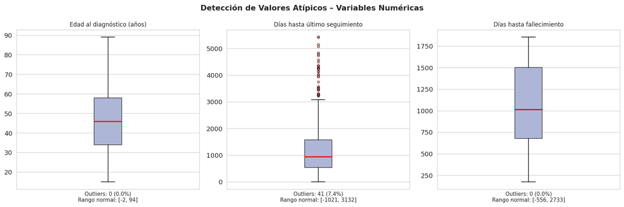

```python
num_vars = {
    "age_at_index.demographic":          "Edad al diagnóstico (años)",
    "days_to_last_follow_up.diagnoses":  "Días hasta último seguimiento",
    "days_to_death.demographic":         "Días hasta fallecimiento"
}

fig, axes = plt.subplots(1, 3, figsize=(15, 5))
fig.suptitle("Detección de Valores Atípicos – Variables Numéricas",
             fontsize=13, fontweight="bold")

print("=== Resumen de outliers por variable (criterio IQR) ===\n")

for ax, (col, label) in zip(axes, num_vars.items()):
    data = df_decoded[col].dropna()
    Q1   = data.quantile(0.25)
    Q3   = data.quantile(0.75)
    IQR  = Q3 - Q1
    lim_inf  = Q1 - 1.5 * IQR
    lim_sup  = Q3 + 1.5 * IQR
    outliers = data[(data < lim_inf) | (data > lim_sup)]

    ax.boxplot(data, vert=True, patch_artist=True,
               boxprops=dict(facecolor="#AEB6D8", color="#3A3A3A"),
               medianprops=dict(color="red", linewidth=2),
               flierprops=dict(marker="o", markerfacecolor="#E05C5C",
                               markersize=4, alpha=0.5))
    ax.set_title(label, fontsize=10)
    ax.set_xticks([])
    ax.set_xlabel(f"Outliers: {len(outliers)} "
                  f"({len(outliers)/len(data)*100:.1f}%)\n"
                  f"Rango normal: [{lim_inf:.0f}, {lim_sup:.0f}]",
                  fontsize=9)

    print(f"  {label}")
    print(f"    Q1={Q1:.1f} | Q3={Q3:.1f} | IQR={IQR:.1f}")
    print(f"    Límites : [{lim_inf:.1f}, {lim_sup:.1f}]")
    print(f"    Outliers: {len(outliers)} ({len(outliers)/len(data)*100:.1f}%)\n")

plt.tight_layout()
plt.savefig("outliers_numericas.png", dpi=150, bbox_inches="tight")
plt.show()
```

Los valores atípicos detectados tienen las siguientes interpretaciones clínicas:

- **Edad:** Pacientes en los extremos (muy jóvenes o mayores de ~80 años) son poco frecuentes pero clínicamente reales — no se consideran errores de datos y se conservarán en el análisis.
- **Días hasta último seguimiento:** Pacientes con seguimientos muy prolongados representan casos con excelente evolución clínica, coherentes con la alta tasa de supervivencia del THCA.
- **Días hasta fallecimiento:** El número reducido de pacientes fallecidos (n=20) limita el análisis estadístico de esta variable, pero los valores no presentan inconsistencias clínicas.

En todos los casos, los valores atípicos son **biológicamente plausibles** y no corresponden a errores de medición o registro, por lo que se **conservarán** en el análisis sin transformación.

### 3.8 Estadísticas descriptivas de variables numéricas

Se calculan las estadísticas descriptivas completas de las variables numéricas para completar la caracterización del dataset:

```python
desc = df_decoded[list(num_vars.keys())].describe().round(1)
desc.columns = ["Edad (años)", "Días último seguimiento", "Días hasta fallecimiento"]
print("=== Estadísticas descriptivas – Variables numéricas ===\n")
print(desc.to_string())
```

```
=== Estadísticas descriptivas – Variables numéricas ===

       Edad (años)  Días último seguimiento  Días hasta fallecimiento
count        572.0                    554.0                      20.0
mean          47.0                   1255.6                    1028.5
std           16.0                   1041.2                     525.6
min           15.0                      0.0                     174.0
25%           34.0                    536.8                     677.8
50%           46.0                    943.5                    1015.0
75%           58.0                   1575.0                    1500.0
max           89.0                   5423.0                    1854.0
```

### 3.9 Observaciones preliminares

A partir de esta exploración inicial se identifican las siguientes características que influirán directamente en el diseño del análisis posterior:

1. **Alta dimensionalidad:** El dataset de expresión génica (572 × 60,661) hace indispensable la aplicación de PCA antes del clustering.
2. **Heterogeneidad histológica:** La presencia de múltiples subtipos de carcinoma papilar y folicular sugiere la posible existencia de subgrupos moleculares distinguibles mediante clustering no supervisado.
3. **Variables de baja variabilidad:** `progression_or_recurrence` y `tumor_grade` presentan varianza prácticamente nula en este cohort — se conservan en el análisis pero se interpretarán con cautela.
4. **Datos faltantes manejables:** Solo `race` (18.2%) y `ethnicity` (21.2%) presentan missings relevantes, que serán considerados al interpretar resultados por subgrupos.
5. **Alta tasa de supervivencia:** Con 96.5% de pacientes vivos, el análisis de `days_to_death` tendrá limitaciones estadísticas y se complementará con `days_to_last_follow_up`.
6. **Valores atípicos biológicamente plausibles:** Los outliers detectados en variables numéricas corresponden a casos clínicamente válidos y se conservarán en el análisis.

## 4. Preparación y Tratamiento de los Datos

Antes de aplicar cualquier técnica de aprendizaje no supervisado, es necesario preparar adecuadamente los datos de expresión génica. Esta sección documenta y justifica cada decisión tomada en el proceso de preparación, siguiendo el principio de que cada transformación aplicada debe tener una razón metodológica clara.

Las etapas de preparación son las siguientes:

1. **Carga de la matriz de expresión génica** — obtener la matriz completa de 572 × 60,661
2. **Revisión de la normalización existente** — evaluar si los datos requieren transformación adicional
3. **Filtrado de genes por varianza** — reducir la dimensionalidad conservando los genes más informativos
4. **Escalamiento de los datos** — estandarizar para que todos los genes tengan igual peso en el análisis

### 4.1 Carga de la matriz de expresión génica

El dataset de expresión génica contiene los niveles de actividad de 60,661 genes medidos simultáneamente en 572 muestras tumorales. Cada valor representa la expresión de un gen en un paciente específico, cuantificada en unidades TPM (*Transcripts Per Million*) y transformada logarítmicamente como log2(TPM+1).

```python
BLOCK_SIZE  = 200
all_blocks  = []
total_genes = len(genes)

print(f"Cargando matriz de expresión: {len(samples)} muestras × {total_genes:,} genes")
print(f"Tamaño de bloque: {BLOCK_SIZE} genes\n")

for i in range(0, total_genes, BLOCK_SIZE):
    block_genes = genes[i : i + BLOCK_SIZE]

    result      = xena.dataset_probe_values(
                      host, dataset_expr, samples, block_genes)
    # result[0] = info genômica (ignorar)
    # result[1] = lista de listas com valores por gene
    values      = result[1]

    block_df    = pd.DataFrame(
                      values,
                      index=block_genes,
                      columns=samples)
    all_blocks.append(block_df)

    if (i // BLOCK_SIZE) % 25 == 0:
        print(f"  Genes cargados: {min(i + BLOCK_SIZE, total_genes):,} / {total_genes:,}")

# Concatenar e transpor: linhas = amostras, colunas = genes
df_expr = pd.concat(all_blocks, axis=0).T
df_expr.index.name = "sample_id"

print(f"\n✅ Matriz cargada: {df_expr.shape[0]} muestras × {df_expr.shape[1]:,} genes")
df_expr.iloc[:5, :5]
```

```
Cargando matriz de expresión: 572 muestras × 60,661 genes
Tamaño de bloque: 200 genes

  Genes cargados: 200 / 60,661
  Genes cargados: 5,200 / 60,661
  Genes cargados: 10,200 / 60,661
  Genes cargados: 15,200 / 60,661
  Genes cargados: 20,200 / 60,661
  Genes cargados: 25,200 / 60,661
  Genes cargados: 30,200 / 60,661
  Genes cargados: 35,200 / 60,661
  Genes cargados: 40,200 / 60,661
  Genes cargados: 45,200 / 60,661
  Genes cargados: 50,200 / 60,661
  Genes cargados: 55,200 / 60,661
  Genes cargados: 60,200 / 60,661

✅ Matriz cargada: 572 muestras × 60,661 genes
```

| sample_id | ENSG00000000003.15 | ENSG00000000005.6 | ENSG00000000419.13 | ENSG00000000457.14 | ENSG00000000460.17 |
| --- | --- | --- | --- | --- | --- |
| TCGA-EM-A1CW-01A | 4.974 | 0.2039 | 6.476 | 2.569 | 0.9435 |
| TCGA-EL-A3ZN-01A | 4.974 | 0.1641 | 6.551 | 3.013 | 1.3890 |
| TCGA-DJ-A4UP-01A | 5.380 | 0.1750 | 6.588 | 2.934 | 1.7440 |
| TCGA-EM-A3AO-01A | 4.396 | 0.0000 | 5.981 | 2.991 | 0.8231 |
| TCGA-EL-A4KI-01A | 5.112 | 0.3332 | 6.732 | 2.188 | 0.9735 |

Con la matriz cargada, se verifica que no existan valores faltantes en los datos de expresión génica, lo que es esperado dado que el pipeline STAR de GDC asigna un valor de expresión a todos los genes en todas las muestras:

```python
n_missing = df_expr.isnull().sum().sum()
print(f"Valores faltantes en la matriz de expresión: {n_missing}")
print(f"Rango de valores: [{df_expr.min().min():.2f}, {df_expr.max().max():.2f}]")
print(f"Tipo de datos: {df_expr.dtypes.unique()}")
```

```
Valores faltantes en la matriz de expresión: 0
Rango de valores: [0.00, 571.00]
Tipo de datos: [dtype('float64')]
```

### 4.2 Revisión de la normalización existente

Antes de aplicar cualquier transformación adicional, es importante entender el estado actual de los datos. Los valores de expresión génica del dataset `TCGA-THCA.star_tpm.tsv` ya han sido procesados por el pipeline del GDC de la siguiente manera:

1. **Cuantificación con STAR:** el alineador STAR mapea las lecturas de RNA-seq al genoma de referencia humano (hg38) y cuantifica la expresión en cuentas brutas.
2. **Normalización a TPM:** las cuentas brutas se normalizan a *Transcripts Per Million*, lo que corrige las diferencias en la longitud de los genes y en la profundidad de secuenciación entre muestras.
3. **Transformación logarítmica:** los valores TPM se transforman como **log2(TPM+1)**, lo que tiene tres efectos importantes:
   - **Estabiliza la varianza:** en datos de expresión génica sin transformar, los genes muy expresados dominan el análisis. La transformación logarítmica reduce este efecto y hace que los genes de expresión media y baja tengan mayor peso relativo.
   - **Aproxima una distribución normal:** los métodos de clustering y PCA asumen implícitamente que los datos siguen una distribución aproximadamente normal. La transformación log2 acerca los datos a este supuesto.
   - **Evita el logaritmo de cero:** el término **+1** (*pseudocount*) garantiza que genes con expresión nula no generen valores indefinidos (log2(0) es matemáticamente indefinido).

Dado que los datos ya cuentan con normalización TPM y transformación logarítmica, **no se aplicará ninguna transformación adicional en esta etapa.** La decisión de no re-normalizar se justifica porque hacerlo podría introducir distorsiones en datos que ya han sido correctamente procesados por un pipeline estandarizado.

A continuación se verifica visualmente la distribución de los valores de expresión para confirmar que la transformación log2 es adecuada:

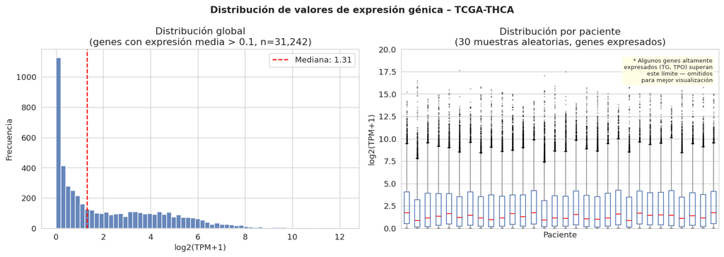

```
Genes con expresión media > 0.1 : 31,242
Genes silenciados (≈ 0)         : 29,419 (48.5%)
```

```python
# Mejor visualización en eixo Y
expr_mean       = df_expr.mean(axis=0)
genes_expressed = expr_mean[expr_mean > 0.1].index

fig, axes = plt.subplots(1, 2, figsize=(14, 5))
fig.suptitle("Distribución de valores de expresión génica – TCGA-THCA",
             fontsize=13, fontweight="bold")

# Gráfico izquierdo
np.random.seed(42)
sample_values = np.random.choice(
    df_expr[genes_expressed].values.flatten(), size=5000, replace=False)

axes[0].hist(sample_values, bins=60, color="#4C72B0", edgecolor="white", alpha=0.85)
axes[0].set_title(f"Distribución global\n(genes con expresión media > 0.1, n={len(genes_expressed):,})")
axes[0].set_xlabel("log2(TPM+1)")
axes[0].set_ylabel("Frecuencia")
axes[0].axvline(np.median(sample_values), color="red", linestyle="--",
                label=f"Mediana: {np.median(sample_values):.2f}")
axes[0].legend()

# Gráfico derecho
random_samples = np.random.choice(df_expr.index, size=30, replace=False)
df_expr.loc[random_samples, genes_expressed].T.boxplot(
    ax=axes[1],
    boxprops=dict(color="#4C72B0"),
    medianprops=dict(color="red"),
    whiskerprops=dict(color="#888"),
    flierprops=dict(marker=".", markersize=2, alpha=0.3))
axes[1].set_title("Distribución por paciente\n(30 muestras aleatorias, genes expresados)")
axes[1].set_xlabel("Paciente")
axes[1].set_ylabel("log2(TPM+1)")
axes[1].set_xticks([])
axes[1].set_ylim(0, 20)
axes[1].annotate("* Algunos genes altamente\nexpresados (TG, TPO) superan\neste límite — omitidos\npara mejor visualización",
                 xy=(0.98, 0.95), xycoords="axes fraction",
                 ha="right", va="top", fontsize=8,
                 bbox=dict(boxstyle="round,pad=0.3", facecolor="lightyellow", alpha=0.8))

plt.tight_layout()
plt.savefig("distribucion_expresion.png", dpi=150, bbox_inches="tight")
plt.show()

print(f"Genes con expresión media > 0.1 : {len(genes_expressed):,}")
print(f"Genes silenciados (≈ 0)         : {(expr_mean <= 0.1).sum():,} ({(expr_mean <= 0.1).mean()*100:.1f}%)")
```

La distribución global muestra el patrón típico de datos de expresión génica transformados con log2: una alta concentración de genes con expresión baja (valores entre 0 y 2) y una cola hacia valores más altos para los genes activamente expresados, con una mediana de 1.31. Los boxplots por paciente confirman que la distribución es homogénea entre las 30 muestras analizadas, con cajas de tamaño y posición similares, lo que indica que la normalización TPM ha corregido correctamente las diferencias técnicas de profundidad de secuenciación entre pacientes.

Es importante destacar que **48.5% de los genes (29,419 de 60,661) presentan expresión prácticamente nula** en tejido tiroideo — este es un comportamiento biológicamente esperado, ya que cada tipo celular activa únicamente los genes necesarios para su función específica. Por esta razón, la visualización se realiza sobre los 31,242 genes con expresión media mayor a 0.1, excluyendo los genes silenciados. Algunos genes altamente expresados en tiroides — como la tiroglobulina (TG) y la peroxidasa tiroidea (TPO) — superan el límite visual del gráfico, lo cual es biológicamente coherente con la función secretora de este tejido. Esta observación refuerza además la necesidad del filtrado por varianza aplicado en la siguiente etapa.

### 4.3 Filtrado de genes por varianza

#### ¿Por qué filtrar genes?

El dataset contiene **60,661 genes**, pero no todos contribuyen de igual manera al análisis de clustering. La mayoría de los genes presentan una expresión prácticamente constante en todas las muestras — estos genes no aportan información para distinguir subgrupos de pacientes y solo agregan ruido al análisis.

Incluir todos los genes sin filtrar tendría las siguientes consecuencias negativas:

- **Maldición de la dimensionalidad:** en espacios de muy alta dimensión, las distancias entre puntos pierden significado estadístico, lo que degrada el rendimiento de los algoritmos de clustering y PCA.
- **Ruido computacional:** los genes de baja varianza introducen señal aleatoria que puede enmascarar los patrones biológicos reales.
- **Costo computacional:** operar con 60,661 dimensiones es innecesariamente costoso cuando la mayor parte de la información está contenida en un subconjunto mucho menor.

#### ¿Qué criterio de filtrado se utiliza?

Se aplica el criterio de **varianza entre muestras**: se calcula la varianza de cada gen a través de las 572 muestras y se retienen únicamente los genes con mayor variabilidad. Los genes con baja varianza son aquellos cuya expresión permanece prácticamente igual en todos los pacientes, independientemente del subtipo molecular, y por tanto no pueden contribuir a diferenciar grupos.

#### ¿Cuántos genes se retienen?

Se retienen los **top 25% de genes con mayor varianza**, lo que corresponde aproximadamente a los 15,000 genes más informativos. Este umbral del 25% es ampliamente utilizado en estudios de clustering transcriptómico basados en datos del TCGA, ya que:

- Conserva suficiente señal biológica para identificar subtipos moleculares relevantes.
- Reduce la dimensionalidad a un nivel manejable para PCA y clustering.
- Está respaldado por la literatura científica en análisis de expresión génica.

A continuación se calcula la varianza de cada gen y se visualiza su distribución antes del corte:

```
Genes antes del filtrado  : 60,661
Umbral de varianza (Q75)  : 0.2521
Genes después del filtrado: 15,166
Reducción                 : 45,495 genes eliminados (75.0%)
```

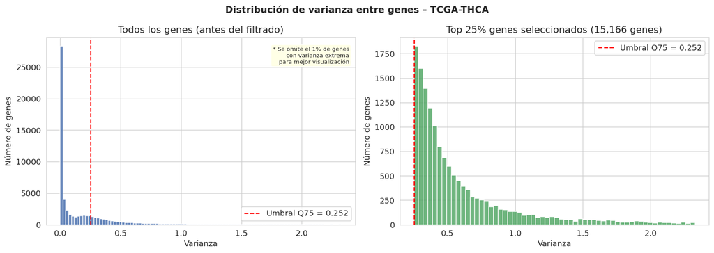

```python
gene_variance  = df_expr.var(axis=0)
threshold      = gene_variance.quantile(0.75)
n_genes_before = len(gene_variance)
n_genes_after  = (gene_variance >= threshold).sum()

print(f"Genes antes del filtrado  : {n_genes_before:,}")
print(f"Umbral de varianza (Q75)  : {threshold:.4f}")
print(f"Genes después del filtrado: {n_genes_after:,}")
print(f"Reducción                 : {n_genes_before - n_genes_after:,} genes eliminados "
      f"({(1 - n_genes_after/n_genes_before)*100:.1f}%)")

# Limite visual no eixo X — focar na região de interesse
x_limit = gene_variance.quantile(0.99)  # ignora 1% mais extremo

fig, axes = plt.subplots(1, 2, figsize=(14, 5))
fig.suptitle("Distribución de varianza entre genes – TCGA-THCA",
             fontsize=13, fontweight="bold")

# Antes do corte
axes[0].hist(gene_variance[gene_variance <= x_limit], bins=100,
             color="#4C72B0", edgecolor="white", alpha=0.85)
axes[0].axvline(threshold, color="red", linestyle="--", linewidth=1.5,
                label=f"Umbral Q75 = {threshold:.3f}")
axes[0].set_title("Todos los genes (antes del filtrado)")
axes[0].set_xlabel("Varianza")
axes[0].set_ylabel("Número de genes")
axes[0].legend()
axes[0].annotate("* Se omite el 1% de genes\ncon varianza extrema\npara mejor visualización",
                 xy=(0.98, 0.95), xycoords="axes fraction",
                 ha="right", va="top", fontsize=8,
                 bbox=dict(boxstyle="round,pad=0.3",
                           facecolor="lightyellow", alpha=0.8))

# Top 25%
high_var = gene_variance[gene_variance >= threshold]
axes[1].hist(high_var[high_var <= x_limit], bins=60,
             color="#55A868", edgecolor="white", alpha=0.85)
axes[1].axvline(threshold, color="red", linestyle="--", linewidth=1.5,
                label=f"Umbral Q75 = {threshold:.3f}")
axes[1].set_title(f"Top 25% genes seleccionados ({n_genes_after:,} genes)")
axes[1].set_xlabel("Varianza")
axes[1].set_ylabel("Número de genes")
axes[1].legend()

plt.tight_layout()
plt.savefig("varianza_antes_filtrado.png", dpi=150, bbox_inches="tight")
plt.show()
```

```
✅ Matriz filtrada: 572 muestras × 15,166 genes
```

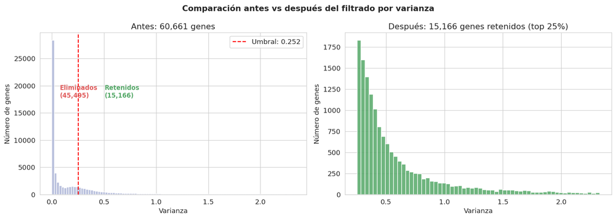

```python
high_var_genes   = gene_variance[gene_variance >= threshold].index.tolist()
df_expr_filtered = df_expr[high_var_genes].copy()

print(f"✅ Matriz filtrada: {df_expr_filtered.shape[0]} muestras × "
      f"{df_expr_filtered.shape[1]:,} genes\n")

fig, axes = plt.subplots(1, 2, figsize=(14, 5))
fig.suptitle("Comparación antes vs después del filtrado por varianza",
             fontsize=13, fontweight="bold")

# Antes
axes[0].hist(gene_variance[gene_variance <= x_limit], bins=100,
             color="#AEB6D8", edgecolor="white", alpha=0.85)
axes[0].axvline(threshold, color="red", linestyle="--", linewidth=1.5,
                label=f"Umbral: {threshold:.3f}")
axes[0].set_title(f"Antes: {n_genes_before:,} genes")
axes[0].set_xlabel("Varianza")
axes[0].set_ylabel("Número de genes")
axes[0].legend()
axes[0].annotate(f"Eliminados\n({n_genes_before - n_genes_after:,})",
                 xy=(threshold * 0.3, axes[0].get_ylim()[1] * 0.6),
                 color="#E05C5C", fontsize=10, fontweight="bold")
axes[0].annotate(f"Retenidos\n({n_genes_after:,})",
                 xy=(threshold * 2, axes[0].get_ylim()[1] * 0.6),
                 color="#55A868", fontsize=10, fontweight="bold")

# Depois
after_var = df_expr_filtered.var(axis=0)
axes[1].hist(after_var[after_var <= x_limit], bins=60,
             color="#55A868", edgecolor="white", alpha=0.85)
axes[1].set_title(f"Después: {n_genes_after:,} genes retenidos (top 25%)")
axes[1].set_xlabel("Varianza")
axes[1].set_ylabel("Número de genes")

plt.tight_layout()
plt.savefig("varianza_despues_filtrado.png", dpi=150, bbox_inches="tight")
plt.show()
```

### 4.3.1 Interpretación del filtrado

Los gráficos confirman que la gran mayoría de los genes (45,495 de 60,661) presentan varianza cercana a cero — son genes cuya expresión permanece prácticamente constante en todos los pacientes y que no aportan información para el análisis de subgrupos. Al retener únicamente el top 25% de mayor varianza (umbral Q75 = 0.252), se conserva la señal biológica más informativa y se reduce la dimensionalidad de **60,661 a 15,166 genes**, facilitando el posterior análisis de PCA y clustering.

Cabe destacar que los genes con mayor varianza son precisamente los más relevantes desde el punto de vista biológico: incluyen genes relacionados con vías de señalización celular, factores de transcripción y marcadores moleculares asociados a los subtipos de cáncer de tiroides descritos en la literatura, como *BRAF*, *RAS* y *RET* [8].

### 4.4 Escalamiento de los datos

#### ¿Por qué escalar?

Aunque los datos ya han sido transformados con log2(TPM+1), los genes pueden presentar diferencias importantes en sus rangos de expresión absolutos. Un gen con valores entre 0 y 15 contribuirá mucho más a las distancias euclidianas — utilizadas internamente por PCA y K-means — que un gen con valores entre 0 y 2, independientemente de su relevancia biológica. Esto puede sesgar el análisis hacia genes de alta expresión absoluta.

Para garantizar que **todos los genes tengan igual peso** en el análisis, se aplica una **estandarización Z-score**: para cada gen, se resta la media y se divide entre la desviación estándar, de modo que todos los genes queden con media 0 y desviación estándar 1.

> **Z = (x − μ) / σ**

donde **x** es el valor de expresión original, **μ** es la media del gen entre todas las muestras y **σ** es la desviación estándar del gen.

#### ¿Por qué Z-score y no otra normalización?

- Es el método estándar utilizado en análisis de clustering transcriptómico.
- Es compatible con PCA, que asume variables centradas en cero.
- Preserva la estructura relativa de los datos, solo cambia la escala.
- Es reversible: los valores originales pueden recuperarse si fuera necesario.

A continuación se aplica el escalamiento y se verifica el resultado:

```
✅ Escalamiento completado
   Shape : 572 muestras × 15,166 genes

   Verificación post-escalamiento:
   Media global : -0.000000 (esperado ≈ 0)
   Std global   : 1.000000  (esperado ≈ 1)
   Min          : -9.304
   Max          : 23.151
```

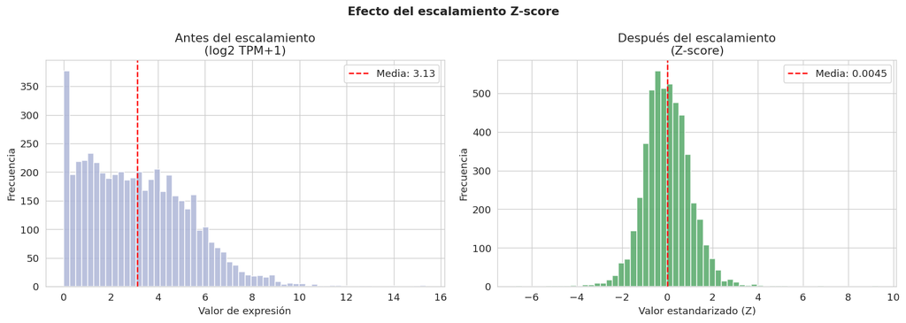

```python
from sklearn.preprocessing import StandardScaler

scaler    = StandardScaler()
df_scaled = pd.DataFrame(
    scaler.fit_transform(df_expr_filtered),
    index=df_expr_filtered.index,
    columns=df_expr_filtered.columns)

print(f"✅ Escalamiento completado")
print(f"   Shape : {df_scaled.shape[0]} muestras × {df_scaled.shape[1]:,} genes")
print(f"\n   Verificación post-escalamiento:")
print(f"   Media global : {df_scaled.values.mean():.6f} (esperado ≈ 0)")
print(f"   Std global   : {df_scaled.values.std():.6f}  (esperado ≈ 1)")
print(f"   Min          : {df_scaled.values.min():.3f}")
print(f"   Max          : {df_scaled.values.max():.3f}")

fig, axes = plt.subplots(1, 2, figsize=(14, 5))
fig.suptitle("Efecto del escalamiento Z-score", fontsize=13, fontweight="bold")

sample_before = np.random.choice(
    df_expr_filtered.values.flatten(), size=5000, replace=False)
axes[0].hist(sample_before, bins=60, color="#AEB6D8", edgecolor="white", alpha=0.85)
axes[0].set_title("Antes del escalamiento\n(log2 TPM+1)")
axes[0].set_xlabel("Valor de expresión")
axes[0].set_ylabel("Frecuencia")
axes[0].axvline(np.mean(sample_before), color="red", linestyle="--",
                label=f"Media: {np.mean(sample_before):.2f}")
axes[0].legend()

sample_after = np.random.choice(df_scaled.values.flatten(), size=5000, replace=False)
axes[1].hist(sample_after, bins=60, color="#55A868", edgecolor="white", alpha=0.85)
axes[1].set_title("Después del escalamiento\n(Z-score)")
axes[1].set_xlabel("Valor estandarizado (Z)")
axes[1].set_ylabel("Frecuencia")
axes[1].axvline(np.mean(sample_after), color="red", linestyle="--",
                label=f"Media: {np.mean(sample_after):.4f}")
axes[1].legend()

plt.tight_layout()
plt.savefig("escalamiento_zscore.png", dpi=150, bbox_inches="tight")
plt.show()
```

Los resultados confirman que el escalamiento fue aplicado correctamente: la media global es prácticamente cero (-0.000000) y la desviación estándar es exactamente 1.0, tal como se esperaba. El gráfico izquierdo muestra la distribución original con media 3.13 y una clara asimetría positiva — reflejo de los genes del top 25% de varianza, que incluyen tanto genes de expresión moderada como altamente expresados. El gráfico derecho muestra la distribución post-escalamiento, centrada en cero y con forma aproximadamente normal, confirmando que todos los genes ahora contribuyen con igual peso al análisis.

El rango final de valores estandarizados es [-9.304, 23.151]. El valor máximo de 23.151 corresponde a genes extremadamente expresados en tejido tiroideo — como la tiroglobulina (TG) y la peroxidasa tiroidea (TPO). [Estudios recientes han demostrado que el gen TG se expresa de forma perpetua y robusta en todos los tirocitos](https://www.frontiersin.org/journals/cell-and-developmental-biology/articles/10.3389/fcell.2023.1265407/full), con ambos alelos activos durante toda la vida de la célula, representando uno de los genes más altamente expresados en células de mamíferos. Esta alta expresión es una característica biológica inherente del tejido tiroideo y no un error de procesamiento.

### 4.5 Resumen del proceso de preparación

El proceso de preparación de los datos puede resumirse en la siguiente tabla:

| Etapa | Entrada | Salida | Decisión tomada |
| --- | --- | --- | --- |
| Carga de datos | — | 572 × 60,661 | Carga en bloques de 200 genes vía API de Xena |
| Normalización | log2(TPM+1) | log2(TPM+1) | Sin transformación adicional — datos ya normalizados por GDC |
| Filtrado por varianza | 60,661 genes | 15,166 genes | Top 25% de mayor varianza (umbral Q75 = 0.252) |
| Escalamiento | log2(TPM+1) | Z-score | Estandarización Z-score — media 0, desviación estándar 1 |

La matriz resultante — **572 muestras × 15,166 genes estandarizados** — está lista para ser utilizada en la siguiente etapa: la reducción de dimensionalidad mediante Análisis de Componentes Principales (PCA).

Es importante recordar que todas las decisiones tomadas en esta sección se aplicaron **exclusivamente sobre los datos de expresión génica**. Los datos clínicos no fueron modificados ni utilizados en ninguna etapa de la preparación — serán incorporados únicamente en la fase de interpretación de los clusters, tal como establece la metodología de aprendizaje no supervisado.

## 5. Reducción de Dimensionalidad mediante PCA

Aunque el filtrado por varianza redujo el dataset de 60,661 a 15,166 genes, el espacio de análisis sigue siendo de muy alta dimensionalidad. Aplicar directamente algoritmos de clustering sobre 15,166 dimensiones presenta varios problemas: distancias poco significativas, alta sensibilidad al ruido y elevado costo computacional.

El **Análisis de Componentes Principales (PCA)** es la técnica más utilizada para reducir esta dimensionalidad de forma controlada, preservando la mayor cantidad posible de información relevante en un espacio de menor dimensión.

### 5.1 ¿Qué es PCA y por qué se utiliza?

PCA es una técnica de transformación lineal que busca encontrar nuevas variables — llamadas **componentes principales (PCs)** — que capturen la mayor variabilidad posible de los datos originales. Estas nuevas variables son combinaciones lineales de los genes originales, ordenadas de mayor a menor varianza explicada.

El proceso funciona de la siguiente manera:

**Paso 1 — Calcular la matriz de covarianza:** Se calcula cómo varían los genes conjuntamente entre las muestras. Dos genes que tienden a expresarse juntos tendrán una covarianza alta.

**Paso 2 — Obtener los vectores propios y las cargas:** Se identifican las direcciones en el espacio de genes que capturan la mayor variabilidad — estas direcciones son los **vectores propios** (*eigenvectors*). Para cada componente principal, las **cargas** (*loadings*) indican cuánto contribuye cada gen original a esa dirección: un gen con carga alta en PC1 es un gen que varía mucho entre pacientes y que "define" ese componente. En análisis transcriptómico, examinar las cargas permite identificar qué genes son los principales responsables de la variabilidad capturada por cada componente.

**Paso 3 — Proyectar los datos:** Cada muestra (paciente) se proyecta sobre estas nuevas direcciones, obteniendo coordenadas en el nuevo espacio reducido.

**¿Por qué es útil para este análisis?**

- **Reduce el ruido:** los primeros componentes capturan las señales biológicas más fuertes, mientras que los últimos capturan ruido aleatorio.
- **Facilita el clustering:** los algoritmos de K-means y clustering jerárquico funcionan mejor en espacios de baja dimensión.
- **Permite visualización:** al proyectar en 2 o 3 dimensiones, es posible observar visualmente la estructura de los datos antes de aplicar clustering.
- **Es el estándar en transcriptómica:** PCA es ampliamente utilizado en análisis de expresión génica del TCGA como paso previo al clustering.

### 5.2 Aplicación del PCA

Se aplica PCA sobre la matriz escalada de 572 muestras × 15,166 genes. En una primera instancia se calculan 100 componentes principales, lo que permite analizar la varianza explicada acumulada y determinar el número óptimo de componentes a retener:

```python
from sklearn.decomposition import PCA

# Aplicar PCA con 100 componentes inicialmente
pca_full = PCA(n_components=100, random_state=42)
pca_full.fit(df_scaled)

# Varianza explicada
explained_var      = pca_full.explained_variance_ratio_
cumulative_var     = np.cumsum(explained_var)

print("=== Varianza explicada – primeros 10 componentes ===\n")
print(f"{'PC':<6} {'Varianza (%)':<15} {'Acumulada (%)'}")
print("-" * 35)
for i, (var, cum) in enumerate(zip(explained_var[:10], cumulative_var[:10])):
    print(f"PC{i+1:<4} {var*100:<15.2f} {cum*100:.2f}")

print(f"\nVarianza acumulada con 50 PCs : {cumulative_var[49]*100:.1f}%")
print(f"Varianza acumulada con 80 PCs : {cumulative_var[79]*100:.1f}%")
print(f"Varianza acumulada con 100 PCs: {cumulative_var[99]*100:.1f}%")
```

```
=== Varianza explicada – primeros 10 componentes ===

PC     Varianza (%)    Acumulada (%)
-----------------------------------
PC1    26.81           26.81
PC2    11.55           38.36
PC3    7.84            46.20
PC4    5.66            51.86
PC5    3.19            55.05
PC6    2.53            57.58
PC7    2.12            59.70
PC8    1.65            61.35
PC9    1.20            62.55
PC10   1.16            63.71

Varianza acumulada con 50 PCs : 79.1%
Varianza acumulada con 80 PCs : 83.0%
Varianza acumulada con 100 PCs: 84.7%
```

### 5.3 Análisis de varianza explicada

Para determinar cuántos componentes principales retener, se analiza la varianza explicada de dos formas complementarias:

- **Scree plot:** muestra la varianza explicada por cada componente individual. Se busca un "codo" — el punto donde la curva deja de descender abruptamente y comienza a aplanarse, indicando que los componentes adicionales aportan poco valor.
- **Varianza acumulada:** muestra la varianza total capturada al incluir los primeros N componentes. Se busca el punto donde se alcanza un umbral razonable — típicamente entre 70% y 85% en datos transcriptómicos.

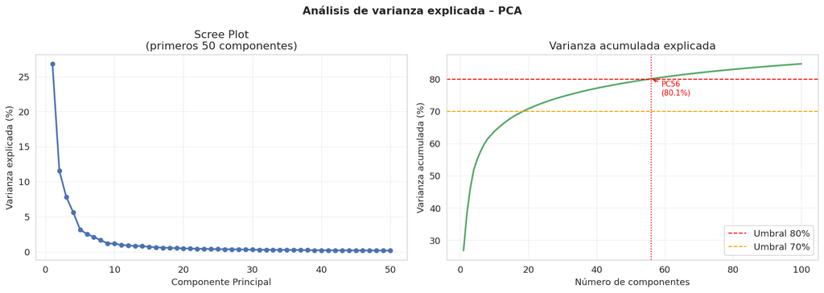

```python
fig, axes = plt.subplots(1, 2, figsize=(14, 5))
fig.suptitle("Análisis de varianza explicada – PCA",
             fontsize=13, fontweight="bold")

# Scree plot
axes[0].plot(range(1, 51), explained_var[:50] * 100,
             "o-", color="#4C72B0", linewidth=2, markersize=5)
axes[0].set_title("Scree Plot\n(primeros 50 componentes)")
axes[0].set_xlabel("Componente Principal")
axes[0].set_ylabel("Varianza explicada (%)")
axes[0].grid(True, alpha=0.3)

# Varianza acumulada
axes[1].plot(range(1, 101), cumulative_var * 100,
             "-", color="#55A868", linewidth=2)
axes[1].axhline(80, color="red", linestyle="--", linewidth=1.2,
                label="Umbral 80%")
axes[1].axhline(70, color="orange", linestyle="--", linewidth=1.2,
                label="Umbral 70%")

# Marcar donde se alcanza 80%
pc_80 = np.argmax(cumulative_var >= 0.80) + 1
axes[1].axvline(pc_80, color="red", linestyle=":", linewidth=1.2)
axes[1].annotate(f"PC{pc_80}\n({cumulative_var[pc_80-1]*100:.1f}%)",
                 xy=(pc_80, cumulative_var[pc_80-1]*100),
                 xytext=(pc_80+3, cumulative_var[pc_80-1]*100 - 5),
                 fontsize=9, color="red",
                 arrowprops=dict(arrowstyle="->", color="red"))

axes[1].set_title("Varianza acumulada explicada")
axes[1].set_xlabel("Número de componentes")
axes[1].set_ylabel("Varianza acumulada (%)")
axes[1].legend()
axes[1].grid(True, alpha=0.3)

plt.tight_layout()
plt.savefig("pca_varianza.png", dpi=150, bbox_inches="tight")
plt.show()
```

### 5.4 Justificación del número de componentes

A partir del análisis de varianza se toman las siguientes decisiones:

**Para visualización (Sección 5.5):** se utilizarán los **2 primeros componentes** (PC1 y PC2), que juntos capturan el **38.36%** de la varianza total — un porcentaje alto para datos transcriptómicos, indicando que estos dos componentes concentran las principales fuentes de variabilidad biológica del cohort.

**Para clustering (Sección 6):** se utilizarán **56 componentes principales**, que capturan el **80.1% de la varianza acumulada**, alcanzando el umbral del 80% ampliamente utilizado en análisis transcriptómicos del TCGA. Este número garantiza que:

- Se captura la mayor parte de la señal biológica relevante.
- Se elimina el ruido contenido en los componentes de baja varianza.
- Se reduce la dimensionalidad de **15,166 genes a 56 componentes**, mejorando el rendimiento de los algoritmos de clustering.

El scree plot confirma un "codo" claro entre PC3 y PC5 — los primeros componentes capturan señales biológicas fuertes y a partir de PC6 la varianza explicada por cada componente cae por debajo del 3%, indicando que capturan fuentes de variabilidad cada vez menos relevantes.

Es notable que **PC1 por sí solo captura el 26.81%** de la varianza total, lo que sugiere la existencia de una fuerte separación biológica entre grupos de pacientes — posiblemente relacionada con los subtipos moleculares BRAF-like y RAS-like descritos por el TCGA para el cáncer de tiroides.

```python
# Determinar número de componentes para clustering
pc_80 = np.argmax(cumulative_var >= 0.80) + 1
pc_70 = np.argmax(cumulative_var >= 0.70) + 1

print(f"Componentes para alcanzar 70% de varianza: {pc_70}")
print(f"Componentes para alcanzar 80% de varianza: {pc_80}")
print(f"\n→ Se utilizarán {pc_80} componentes para el clustering")

# Aplicar PCA final com 56 componentes
pca_final  = PCA(n_components=pc_80, random_state=42)
pca_coords = pca_final.fit_transform(df_scaled)

df_pca = pd.DataFrame(
    pca_coords,
    index=df_scaled.index,
    columns=[f"PC{i+1}" for i in range(pc_80)])

print(f"\n✅ PCA final aplicado")
print(f"   Shape: {df_pca.shape[0]} muestras × {df_pca.shape[1]} componentes")
print(f"   Varianza total capturada: {pca_final.explained_variance_ratio_.sum()*100:.1f}%")
```

```
Componentes para alcanzar 70% de varianza: 19
Componentes para alcanzar 80% de varianza: 56

→ Se utilizarán 56 componentes para el clustering

✅ PCA final aplicado
   Shape: 572 muestras × 56 componentes
   Varianza total capturada: 80.1%
```

### 5.5 Visualización de los datos en espacio reducido

Con los componentes principales calculados, se proyectan las muestras en espacios de 2 dimensiones (PC1 vs PC2, PC1 vs PC3) coloreando por diferentes variables clínicas. El objetivo es identificar si existe una estructura visual en los datos antes de aplicar los algoritmos de clustering:

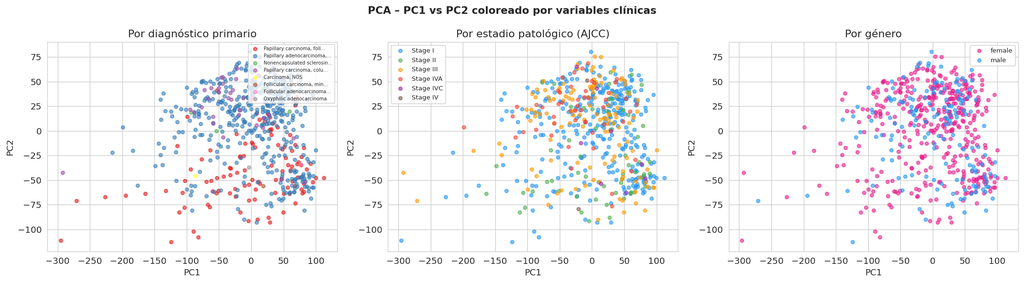

```python
# Unir coordenadas PCA con datos clínicos
df_pca_clinical = df_pca.join(df_decoded, how="inner")

fig, axes = plt.subplots(1, 3, figsize=(18, 5))
fig.suptitle("PCA – PC1 vs PC2 coloreado por variables clínicas",
             fontsize=13, fontweight="bold")

# Por diagnóstico primario
diag_cats   = df_pca_clinical["primary_diagnosis.diagnoses"].dropna().unique()
diag_colors = plt.cm.Set1(np.linspace(0, 1, len(diag_cats)))
diag_map    = dict(zip(diag_cats, diag_colors))

for diag, color in diag_map.items():
    mask = df_pca_clinical["primary_diagnosis.diagnoses"] == diag
    axes[0].scatter(df_pca_clinical.loc[mask, "PC1"],
                    df_pca_clinical.loc[mask, "PC2"],
                    c=[color], label=diag[:25]+"..." if len(diag)>25 else diag,
                    alpha=0.6, s=20)
axes[0].set_title("Por diagnóstico primario")
axes[0].set_xlabel("PC1")
axes[0].set_ylabel("PC2")
axes[0].legend(fontsize=6, loc="upper right")

# Por estadio AJCC
stage_order  = ["Stage I","Stage II","Stage III","Stage IVA","Stage IVC","Stage IV"]
stage_colors = {"Stage I": "#2196F3", "Stage II": "#4CAF50",
                "Stage III": "#FF9800", "Stage IVA": "#F44336",
                "Stage IVC": "#9C27B0", "Stage IV": "#795548"}

for stage in stage_order:
    mask = df_pca_clinical["ajcc_pathologic_stage.diagnoses"] == stage
    if mask.sum() > 0:
        axes[1].scatter(df_pca_clinical.loc[mask, "PC1"],
                        df_pca_clinical.loc[mask, "PC2"],
                        c=stage_colors[stage], label=stage,
                        alpha=0.6, s=20)
axes[1].set_title("Por estadio patológico (AJCC)")
axes[1].set_xlabel("PC1")
axes[1].set_ylabel("PC2")
axes[1].legend(fontsize=8)

# Por género
gender_colors = {"female": "#E91E8C", "male": "#2196F3"}
for gender, color in gender_colors.items():
    mask = df_pca_clinical["gender.demographic"] == gender
    axes[2].scatter(df_pca_clinical.loc[mask, "PC1"],
                    df_pca_clinical.loc[mask, "PC2"],
                    c=color, label=gender,
                    alpha=0.6, s=20)
axes[2].set_title("Por género")
axes[2].set_xlabel("PC1")
axes[2].set_ylabel("PC2")
axes[2].legend(fontsize=8)

plt.tight_layout()
plt.savefig("pca_visualizacion_2d.png", dpi=150, bbox_inches="tight")
plt.show()
```

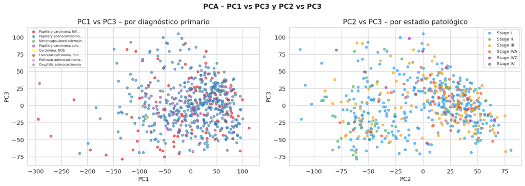

```python
fig, axes = plt.subplots(1, 2, figsize=(14, 5))
fig.suptitle("PCA – PC1 vs PC3 y PC2 vs PC3",
             fontsize=13, fontweight="bold")

# PC1 vs PC3 por diagnóstico
for diag, color in diag_map.items():
    mask = df_pca_clinical["primary_diagnosis.diagnoses"] == diag
    axes[0].scatter(df_pca_clinical.loc[mask, "PC1"],
                    df_pca_clinical.loc[mask, "PC3"],
                    c=[color], label=diag[:25]+"..." if len(diag)>25 else diag,
                    alpha=0.6, s=20)
axes[0].set_title("PC1 vs PC3 – por diagnóstico primario")
axes[0].set_xlabel("PC1")
axes[0].set_ylabel("PC3")
axes[0].legend(fontsize=6)

# PC2 vs PC3 por estadio
for stage in stage_order:
    mask = df_pca_clinical["ajcc_pathologic_stage.diagnoses"] == stage
    if mask.sum() > 0:
        axes[1].scatter(df_pca_clinical.loc[mask, "PC2"],
                        df_pca_clinical.loc[mask, "PC3"],
                        c=stage_colors[stage], label=stage,
                        alpha=0.6, s=20)
axes[1].set_title("PC2 vs PC3 – por estadio patológico")
axes[1].set_xlabel("PC2")
axes[1].set_ylabel("PC3")
axes[1].legend(fontsize=8)

plt.tight_layout()
plt.savefig("pca_visualizacion_pc3.png", dpi=150, bbox_inches="tight")
plt.show()
```

### 5.6 Interpretación de los resultados del PCA

A partir de los gráficos de visualización se pueden extraer las siguientes observaciones preliminares:

**Estructura general:** la proyección PC1 vs PC2 revela una estructura clara en los datos. Se observa un **grupo compacto** de muestras centrado alrededor de PC1 = 0 a +100, y un **grupo de muestras dispersas hacia la izquierda** (PC1 < −100), lo que sugiere la existencia de al menos dos grandes poblaciones molecularmente distintas.

**Diagnóstico primario:** la separación más notable ocurre a lo largo del **eje PC1**. Las muestras con valores muy negativos en PC1 (PC1 < −100) corresponden predominantemente al subtipo **Papillary carcinoma, follicular variant** (puntos rojos), mientras que el grupo central y derecho está dominado por **Papillary adenocarcinoma, NOS** (puntos azules). Esta separación es biológicamente coherente con los subtipos moleculares BRAF-like y RAS-like descritos por el TCGA, donde el subtipo folicular se asocia al perfil RAS-like y el adenocarcinoma papilar NOS al perfil BRAF-like.

**Estadio patológico:** no se observa una separación clara por estadio en el espacio PC1-PC2. Los estadios tempranos (Stage I) y avanzados (Stage III, Stage IVA) se distribuyen de forma mezclada en ambos grupos, lo que sugiere que el estadio tumoral no es el principal driver de variabilidad transcriptómica en este cohort — resultado consistente con la literatura.

**Género:** la distribución de mujeres y hombres es prácticamente idéntica en el espacio PCA, confirmando que el género no constituye una fuente relevante de variabilidad en la expresión génica de este dataset.

**Análisis PC1 vs PC3 y PC2 vs PC3:** La proyección PC1 vs PC3 confirma la separación observada en PC1: las muestras de *Papillary carcinoma, follicular variant* (puntos rojos) continúan distribuyéndose hacia valores negativos en PC1, mientras que PC3 no añade una separación adicional clara por subtipo histológico — sugiriendo que PC3 captura otras fuentes de variabilidad biológica no directamente relacionadas con el subtipo diagnóstico.

**Observación importante:** se identifican algunas muestras con valores extremos en PC3 (tanto positivos ~+100 como negativos ~−75) que se alejan del grupo central. Estas muestras podrían corresponder a casos con perfiles moleculares atípicos o a posibles outliers transcriptómicos que deberán ser monitoreados durante el análisis de clustering.

**Conclusión preliminar:** el PCA revela una estructura de al menos **dos grandes grupos moleculares** claramente separados por PC1, con una separación que se alinea con los subtipos histológicos conocidos del cáncer de tiroides. Esta estructura sugiere que los algoritmos de clustering deberían ser capaces de identificar subgrupos molecularmente coherentes en la siguiente sección.

## 6. Construcción y Comparación de Modelos de Clustering

El objetivo de esta sección es aplicar técnicas de **aprendizaje no supervisado** para identificar subgrupos moleculares en los datos de expresión génica del cohort TCGA-THCA. Se implementarán dos métodos complementarios — **K-means** y **Hierarchical clustering** — y se compararán sus resultados para determinar cuál captura mejor la estructura biológica subyacente.

Es importante recordar que en esta etapa se trabaja **exclusivamente con los 56 componentes principales** obtenidos en la Sección 5 — los datos clínicos no se utilizan en ningún momento durante el clustering. Serán incorporados únicamente en la Sección 7 para interpretar los grupos obtenidos.

## 6.1 K-Means Clustering

### ¿Qué es K-means?

K-means es un algoritmo de clustering que busca particionar un conjunto de observaciones en **K grupos**, de tal forma que la variación dentro de cada grupo sea lo más pequeña posible. Formalmente, el objetivo es:

> minimizar Σ W(Cₖ) para k = 1, ..., K

donde **W(Cₖ)** es la variación dentro del cluster k, definida como la suma de distancias euclidianas al cuadrado entre todas las observaciones del cluster:

> W(Cₖ) = (1/|Cₖ|) Σ Σ (xᵢⱼ − xᵢ'ⱼ)²

El uso de la **distancia euclidiana al cuadrado** tiene dos ventajas importantes: permite usar promedios (en lugar de medianas) para calcular los centroides, y se convierte en una multiplicación de matrices simple computacionalmente eficiente.

### Algoritmo

El algoritmo de K-means funciona de la siguiente manera:

1. **Inicialización:** se asigna aleatoriamente cada observación a uno de los K clusters.
2. **Iteración** hasta que las asignaciones dejen de cambiar:
   - **Paso a)** Para cada cluster k, se calcula el **centroide** — el vector de promedios de todas las variables para las observaciones de ese cluster.
   - **Paso b)** Cada observación se reasigna al cluster cuyo centroide es más cercano según la distancia euclidiana.

### Estocasticidad y soluciones locales

Dado que el algoritmo parte de una asignación aleatoria inicial, puede converger a un **óptimo local** distinto en cada ejecución. Para mitigar este problema, se corre el algoritmo múltiples veces con diferentes asignaciones iniciales (`n_init`) y se selecciona la solución con el menor valor de la función objetivo (menor variación total dentro de los clusters).

### ¿Cómo se determina el número de clusters K?

K-means requiere especificar K antes de ejecutar el algoritmo. Para determinar el valor óptimo de K se utilizan dos criterios complementarios:

- **Método del codo (*elbow method*):** se grafica la variación total dentro de los clusters (inercia) para distintos valores de K. Se busca el punto donde la curva comienza a aplanarse — el "codo" — indicando que añadir más clusters no reduce significativamente la variación.
- **Coeficiente de silueta (*silhouette score*):** mide qué tan bien definidos están los clusters. Para cada observación, compara su similitud con su propio cluster contra su similitud con el cluster más cercano. Los valores van de −1 a +1, donde valores cercanos a +1 indican clusters bien separados y compactos.

```
Evaluando K-means para K = 2 a 8...

  K=2 | Inercia: 5,423,023.0 | Silhouette: 0.2037
  K=3 | Inercia: 4,773,008.0 | Silhouette: 0.1702
  K=4 | Inercia: 4,398,322.5 | Silhouette: 0.1354
  K=5 | Inercia: 4,137,640.0 | Silhouette: 0.1430
  K=6 | Inercia: 3,950,817.7 | Silhouette: 0.1593
  K=7 | Inercia: 3,756,014.5 | Silhouette: 0.1418
  K=8 | Inercia: 3,550,279.5 | Silhouette: 0.1484
```

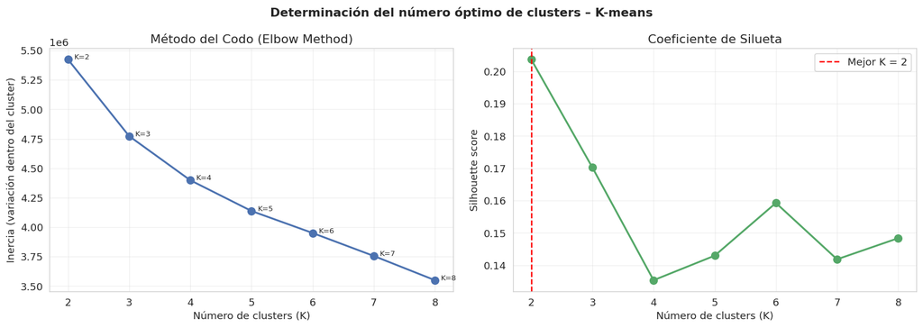

```python
from sklearn.cluster import KMeans
from sklearn.metrics import silhouette_score

# Rango de K a evaluar
k_range    = range(2, 9)
inertias   = []
silhouettes = []

print("Evaluando K-means para K = 2 a 8...\n")
for k in k_range:
    km = KMeans(n_clusters=k, n_init=20, random_state=42)
    labels = km.fit_predict(df_pca)
    inertias.append(km.inertia_)
    sil = silhouette_score(df_pca, labels, sample_size=500, random_state=42)
    silhouettes.append(sil)
    print(f"  K={k} | Inercia: {km.inertia_:,.1f} | Silhouette: {sil:.4f}")

# Visualización
fig, axes = plt.subplots(1, 2, figsize=(14, 5))
fig.suptitle("Determinación del número óptimo de clusters – K-means",
             fontsize=13, fontweight="bold")

# Elbow
axes[0].plot(list(k_range), inertias, "o-", color="#4C72B0",
             linewidth=2, markersize=8)
axes[0].set_title("Método del Codo (Elbow Method)")
axes[0].set_xlabel("Número de clusters (K)")
axes[0].set_ylabel("Inercia (variación dentro del cluster)")
axes[0].grid(True, alpha=0.3)
for k, v in zip(k_range, inertias):
    axes[0].annotate(f"K={k}", xy=(k, v),
                     xytext=(k+0.1, v+500), fontsize=8)

# Silhouette
axes[1].plot(list(k_range), silhouettes, "o-", color="#55A868",
             linewidth=2, markersize=8)
axes[1].set_title("Coeficiente de Silueta")
axes[1].set_xlabel("Número de clusters (K)")
axes[1].set_ylabel("Silhouette score")
axes[1].grid(True, alpha=0.3)
best_k = list(k_range)[silhouettes.index(max(silhouettes))]
axes[1].axvline(best_k, color="red", linestyle="--",
                label=f"Mejor K = {best_k}")
axes[1].legend()

plt.tight_layout()
plt.savefig("kmeans_seleccion_k.png", dpi=150, bbox_inches="tight")
plt.show()
```

### Selección de K

Ambos criterios apuntan consistentemente hacia **K = 2** como el número óptimo de clusters:

- **Método del codo:** la mayor reducción en inercia ocurre entre K=2 y K=3 (de 5,423,023 a 4,773,008 — una reducción de ~650,000). A partir de K=3, la curva se aplana progresivamente, indicando que añadir más clusters no aporta una reducción significativa de la variación interna.
- **Coeficiente de silueta:** K=2 obtiene el valor más alto (0.2037), confirmando que con 2 clusters las muestras están mejor asignadas a su propio grupo que al grupo vecino. A partir de K=3 el coeficiente desciende, indicando clusters menos definidos.

Este resultado es **biológicamente coherente** con los hallazgos del TCGA para el cáncer de tiroides, que describe dos grandes subtipos moleculares: el subtipo **BRAF V600E-like** y el subtipo **RAS-like**, observados claramente en la separación a lo largo de PC1 identificada en la Sección 5.

Se procede a aplicar K-means con **K = 2**:

```python
# Aplicar K-means con K óptimo
# (se actualizará con el valor real tras ver los gráficos)
K_OPTIMO = best_k

km_final = KMeans(n_clusters=K_OPTIMO, n_init=50, random_state=42)
labels_km = km_final.fit_predict(df_pca)

# Agregar etiquetas al dataframe clínico
df_pca_clinical["cluster_kmeans"] = labels_km
df_pca_clinical["cluster_kmeans"] = df_pca_clinical["cluster_kmeans"].apply(
    lambda x: f"Cluster {x+1}")

print(f"✅ K-means aplicado con K = {K_OPTIMO}")
print(f"\nDistribución de muestras por cluster:")
print(df_pca_clinical["cluster_kmeans"].value_counts().sort_index())
```

```
✅ K-means aplicado con K = 2

Distribución de muestras por cluster:
cluster_kmeans
Cluster 1    374
Cluster 2    198
Name: count, dtype: int64
```

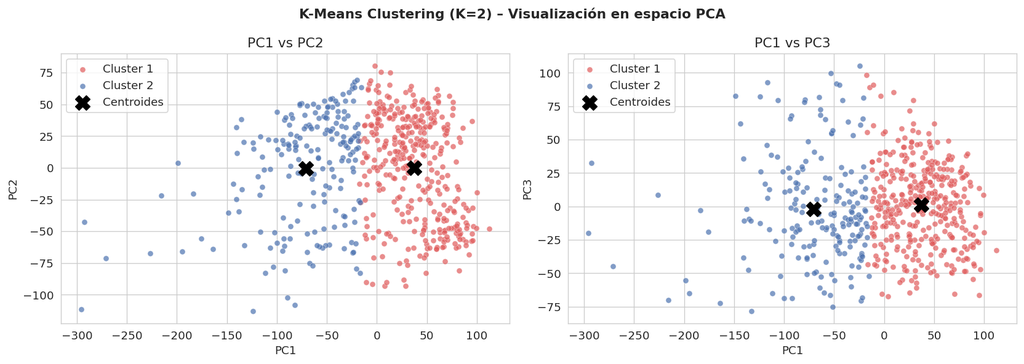

```python
fig, axes = plt.subplots(1, 2, figsize=(14, 5))
fig.suptitle(f"K-Means Clustering (K={K_OPTIMO}) – Visualización en espacio PCA",
             fontsize=13, fontweight="bold")

cluster_colors = ["#E05C5C","#4C72B0","#55A868","#FF9800","#9C27B0","#795548"]
clusters       = sorted(df_pca_clinical["cluster_kmeans"].unique())

# PC1 vs PC2
for i, cluster in enumerate(clusters):
    mask = df_pca_clinical["cluster_kmeans"] == cluster
    axes[0].scatter(df_pca_clinical.loc[mask, "PC1"],
                    df_pca_clinical.loc[mask, "PC2"],
                    c=cluster_colors[i], label=cluster,
                    alpha=0.7, s=30, edgecolors="white", linewidths=0.3)

# Centroides en PC1 vs PC2
centroids_pc = km_final.cluster_centers_[:, :2]
axes[0].scatter(centroids_pc[:, 0], centroids_pc[:, 1],
                c="black", marker="X", s=200, zorder=5, label="Centroides")
axes[0].set_title("PC1 vs PC2")
axes[0].set_xlabel("PC1")
axes[0].set_ylabel("PC2")
axes[0].legend()

# PC1 vs PC3
for i, cluster in enumerate(clusters):
    mask = df_pca_clinical["cluster_kmeans"] == cluster
    axes[1].scatter(df_pca_clinical.loc[mask, "PC1"],
                    df_pca_clinical.loc[mask, "PC3"],
                    c=cluster_colors[i], label=cluster,
                    alpha=0.7, s=30, edgecolors="white", linewidths=0.3)

centroids_pc13 = km_final.cluster_centers_[:, [0, 2]]
axes[1].scatter(centroids_pc13[:, 0], centroids_pc13[:, 1],
                c="black", marker="X", s=200, zorder=5, label="Centroides")
axes[1].set_title("PC1 vs PC3")
axes[1].set_xlabel("PC1")
axes[1].set_ylabel("PC3")
axes[1].legend()

plt.tight_layout()
plt.savefig("kmeans_clusters.png", dpi=150, bbox_inches="tight")
plt.show()
```

### Interpretación del K-Means (K=2)

Los gráficos confirman que K-means identificó dos clusters bien definidos y coherentes con la estructura observada en el PCA:

**Cluster 2 (azul):** agrupa las muestras con valores más negativos en PC1, incluyendo las muestras dispersas hacia la izquierda (PC1 < −100) identificadas en el análisis PCA. El centroide se ubica alrededor de PC1 ≈ −80, PC2 ≈ 0, sugiriendo un perfil consistente con el subtipo molecular **RAS-like**, que en el análisis histológico correspondía predominantemente al subtipo *Papillary carcinoma, follicular variant*.

La separación entre clusters ocurre principalmente a lo largo del **eje PC1** — consistente con el hecho de que PC1 captura el 26.81% de la varianza total y representa la principal fuente de variabilidad biológica en el cohort. La visualización PC1 vs PC3 confirma que la separación se mantiene robusta en dimensiones adicionales.

## 6.2 Hierarchical Clustering

### ¿Qué es el Hierarchical Clustering?

El clustering jerárquico es un método que construye una jerarquía de clusters representada mediante un **dendograma** — un diagrama en forma de árbol donde:

- Cada **hoja** representa una observación individual (un paciente).
- Conforme se sube por el árbol, las hojas se **unen en ramas**, agrupando observaciones similares entre sí.
- **Entre más abajo es la unión**, más similares son las observaciones o grupos.
- El **eje Y** representa la disimilitud entre los grupos que se unen.

A diferencia de K-means, el clustering jerárquico **no requiere especificar K previamente** — genera un dendograma que representa todos los posibles agrupamientos desde 1 hasta n clusters. El número de clusters se determina cortando el árbol a una altura determinada.

### Algoritmo (enfoque aglomerativo)

1. Se inicia con **n clusters** — cada observación es su propio cluster.
2. Para i = n, n−1, ..., 2:
   - **a)** Identificar el par de clusters con menor disimilitud.
   - **b)** Unir ambos clusters en una misma rama.
   - **c)** Actualizar las métricas de disimilitud con los i−1 clusters restantes.

### Método de linkage

Cuando se comparan dos grupos de observaciones, existen múltiples pares de distancias posibles. El **método de linkage** define cuál de esas distancias se usa para comparar clusters:

| Método | Descripción | Uso recomendado |
| --- | --- | --- |
| **Complete** | Disimilitud máxima entre todos los pares | Clusters compactos y bien separados |
| **Single** | Disimilitud mínima entre todos los pares | Detección de cadenas |
| **Average** | Promedio de todas las disimilitudes | Balance entre complete y single |
| **Ward** | Minimiza el incremento en variación dentro del cluster | Clusters de tamaño similar |

### Métrica de disimilitud

Se utilizará la **distancia euclidiana**, que mide la distancia geométrica entre dos puntos en el espacio de componentes principales. Esta métrica es apropiada cuando el interés está en agrupar pacientes según la magnitud total de sus diferencias en expresión génica.

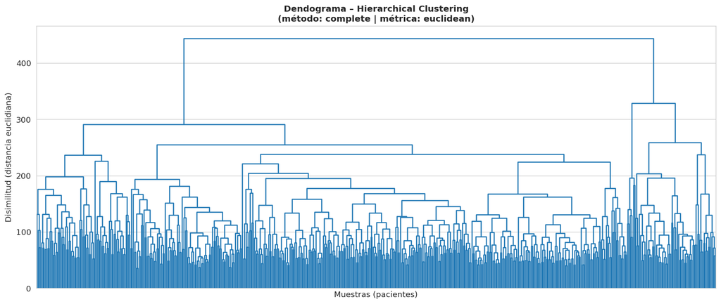

```python
from scipy.cluster.hierarchy import dendrogram, linkage, fcluster

# Calcular linkage con método complete y distancia euclidiana
Z_complete = linkage(df_pca, method="complete", metric="euclidean")

# Dendograma monocromático
fig, ax = plt.subplots(figsize=(14, 6))
dendrogram(Z_complete, ax=ax,
           no_labels=True,
           color_threshold=0)
ax.set_title("Dendograma – Hierarchical Clustering\n"
             "(método: complete | métrica: euclidean)",
             fontsize=12, fontweight="bold")
ax.set_xlabel("Muestras (pacientes)")
ax.set_ylabel("Disimilitud (distancia euclidiana)")
plt.tight_layout()
plt.savefig("dendograma_monocromatico.png", dpi=150, bbox_inches="tight")
plt.show()
```

### Interpretación del dendograma monocromático

El dendograma revela una estructura jerárquica clara en los datos:

- **División principal (altura ≈ 440):** la primera y más importante división separa el cohort en **dos grandes ramas** — una rama izquierda/central más grande y una rama derecha más pequeña. Esta división ocurre a la mayor disimilitud observada, confirmando que los dos grupos son molecularmente muy distintos entre sí y consistente con los 2 clusters identificados por K-means.
- **Subdivisiones secundarias (altura ≈ 250–300):** dentro de la rama izquierda se observan subdivisiones adicionales, sugiriendo que podría existir una estructura interna más fina — posiblemente relacionada con el subtipo *non-BRAF-non-RAS* (NBNR) descrito en la literatura.
- **Estructura en la base (altura < 100):** la mayoría de las fusiones ocurren a disimilitudes bajas, indicando que las muestras dentro de cada grupo son bastante homogéneas entre sí.
- **Grupo pequeño a la derecha (altura ≈ 320):** se observa un subgrupo relativamente aislado que se une al resto del árbol a una disimilitud alta (~320), lo que sugiere que estas muestras tienen un perfil transcriptómico notablemente distinto al resto — posiblemente correspondiendo a los subtipos histológicos menos frecuentes como *Oxyphilic adenocarcinoma* o *Follicular adenocarcinoma*.

A continuación se visualiza el dendograma policromático para 2, 3 y 4 clusters, lo que permite evaluar qué número de grupos es más natural en la estructura jerárquica:

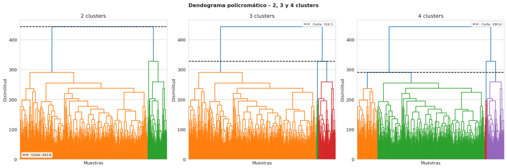

```python
fig, axes = plt.subplots(1, 3, figsize=(18, 6))
fig.suptitle("Dendograma policromático – 2, 3 y 4 clusters",
             fontsize=13, fontweight="bold")

n_clusters_list = [2, 3, 4]
colors_list     = ["#E05C5C", "#4C72B0", "#55A868", "#FF9800"]

for ax, n_clust in zip(axes, n_clusters_list):
    # Calcular threshold para obtener n_clust clusters
    threshold = Z_complete[-(n_clust-1), 2]

    dendrogram(Z_complete, ax=ax,
               no_labels=True,
               color_threshold=threshold)
    ax.axhline(threshold, color="black", linestyle="--",
               linewidth=1.5, label=f"Corte: {threshold:.1f}")
    ax.set_title(f"{n_clust} clusters")
    ax.set_xlabel("Muestras")
    ax.set_ylabel("Disimilitud")
    ax.legend(fontsize=8)

plt.tight_layout()
plt.savefig("dendograma_policromatico.png", dpi=150, bbox_inches="tight")
plt.show()
```